# Final Project

Vajsz Kornel

2023-01-03

# Proper textual explanations, and commented code

# Exploratory data analysis with useful visualizations

# Testing of hypothesis by building statistical model(s)

# Verifying that statistical tests are reliable and valid (e.g. residual diagnostics, assumption checks)

# Introduction

In this final project assignment I am exploring the records of Traumatic Brain Injury as presented by Brain Injury Association of America.

```r
tbiAge <- read_csv("https://raw.githubusercontent.com/rfordatascience/tidytuesday/master/data/2020/2020-03-24/tbi_age.csv")
tbiMilitary <-read_csv("https://raw.githubusercontent.com/rfordatascience/tidytuesday/master/data/2020/2020-03-24/tbi_military.csv")
tbiYear <- read_csv("https://raw.githubusercontent.com/rfordatascience/tidytuesday/master/data/2020/2020-03-24/tbi_year.csv")
```

# Preliminary exploration

```r
glimpse(tbiAge)
```

```
## Rows: 231
## Columns: 5
## $ age_group        <chr> "0-17", "0-17", "0-17", "0-17", "0-17", "0-17", "0-17…
## $ type             <chr> "Emergency Department Visit", "Emergency Department V…
## $ injury_mechanism <chr> "Motor Vehicle Crashes", "Unintentional Falls", "Unin…
## $ number_est       <dbl> 47138, 397190, 229236, 55785, NA, 24360, 57983, 5464,…
## $ rate_est         <dbl> 64.1, 539.8, 311.6, 75.8, NA, 33.1, 78.8, 27.5, 1161.…
```

```r
glimpse(tbiMilitary)
```

```
## Rows: 450
## Columns: 5
## $ service   <chr> "Army", "Army", "Army", "Army", "Army", "Army", "Army", "Arm…
## $ component <chr> "Active", "Active", "Active", "Active", "Active", "Guard", "…
## $ severity  <chr> "Penetrating", "Severe", "Moderate", "Mild", "Not Classifiab…
## $ diagnosed <dbl> 189, 102, 709, 5896, 122, 33, 26, 177, 1332, 29, 12, 11, 63,…
## $ year      <dbl> 2006, 2006, 2006, 2006, 2006, 2006, 2006, 2006, 2006, 2006, …
```

```r
glimpse(tbiYear)
```

```
## Rows: 216
## Columns: 5
## $ injury_mechanism <chr> "Motor vehicle crashes", "Motor vehicle crashes", "Mo…
## $ type             <chr> "Emergency Department Visit", "Emergency Department V…
## $ year             <dbl> 2006, 2007, 2008, 2009, 2010, 2011, 2012, 2013, 2014,…
## $ rate_est         <dbl> 85.3, 83.8, 83.9, 88.7, 95.3, 98.7, 99.9, 99.6, 106.0…
## $ number_est       <dbl> 254793, 252459, 254391, 270240, 292942, 305694, 31127…
```

```r
lapply(tbiAge, unique)
```

```
## $age_group
##  [1] "0-17"  "0-4"   "5-14"  "15-24" "25-34" "35-44" "45-54" "55-64" "65-74"
## [10] "75+"   "Total"
##
## $type
## [1] "Emergency Department Visit" "Hospitalizations"
## [3] "Deaths"
##
## $injury_mechanism
## [1] "Motor Vehicle Crashes"
## [2] "Unintentional Falls"
## [3] "Unintentionally struck by or against an object"
## [4] "Other unintentional injury, mechanism unspecified"
## [5] "Intentional self-harm"
## [6] "Assault"
```

[output cut: 45 more lines]

```r
lapply(tbiMilitary, unique)
```

```
## $service
## [1] "Army"      "Navy"      "Air Force" "Marines"
##
## $component
## [1] "Active"  "Guard"   "Reserve"
##
## $severity
## [1] "Penetrating"      "Severe"           "Moderate"         "Mild"
## [5] "Not Classifiable"
##
## $diagnosed
##   [1]   189   102   709  5896   122    33    26   177  1332    29    12    11
##  [13]    63   541    28   217  2143    56    NA     1    19   165     5    21
##  [25]    24   194  1966    30     4    20   167     8     2   114     3    53
##  [37]   269  1891    23   222     7   237   134  1126  8977   249   246  2418
```

[output cut: 19 more lines]

```r
lapply(tbiYear, unique)
```

```
## $injury_mechanism
## [1] "Motor vehicle crashes"
## [2] "Unintentional falls"
## [3] "Unintentionally struck by or against an object"
## [4] "Other unintentional injury, mechanism unspecified"
## [5] "Intentional self-harm"
## [6] "Assault"
## [7] "Other or no mechanism specified"
## [8] "Total"
##
## $type
## [1] "Emergency Department Visit" "Hospitalizations"
## [3] "Deaths"
##
## $year
```

[output cut: 40 more lines]

```r
colSums(is.na(tbiAge))
```

```
##        age_group             type injury_mechanism       number_est
##                0                0                0               11
##         rate_est
##               11
```

```r
# Replacing NA with zero values
tbiAge[is.na(tbiAge)] = 0

colSums(is.na(tbiMilitary))
```

```
##   service component  severity diagnosed      year
##         0         0         0        12         0
```

```r
# Replacing NA with zero values
tbiMilitary[is.na(tbiMilitary)] = 0

colSums(is.na(tbiYear))
```

```
## injury_mechanism             type             year         rate_est
##                0                0                0                0
##       number_est
##               27
```

```r
# Calculating missing TBI numbers
tbiYearTotal <- tbiYear %>%
  filter(injury_mechanism != 'Total') %>%
  group_by(type, year) %>%
  summarize(number_est = sum(number_est))
tbiYear <- left_join(tbiYear, tbiYearTotal, by = c("type","year")) %>%
  mutate(number_est = ifelse(is.na(number_est.x), number_est.y, number_est.x)) %>%
  select(-number_est.y, -number_est.x)
```

The data collected shows a time period from 2006 to 2014. There are three groups of outcome of TBI presented in the data - Emergency Department Visits; Hospitalizations; and Death. The groups of mechanism of injury are Assault; Intentional self-harm; Motor vehicle crashes; Unintentional falls; Unintentionally struck by or against an object; Other unintentional injuries; or Other / no specified injuries.

There age range is grouped for patients with the following granularity groups: 0-4; 5-14; 15-24; 25-34; 35-44; 45-54; 55-64; 65-74; and 75+. There is also a separate grouping which has 0-17 age group that has overlap with the first 3 age groups.

The data has both estimated overall cases reported as well as rates of x/100,000.

There is a separate table for TBI in military context on a 4 level severity scale (Mild; Moderate; Severe; Penetrating). The military personnel are differentiated by service branch (Army; Navy; Air Force; Marines) and component status (Active; Guard; Reserve).

The primary key dimensions for the tables are the following: TBI_AGE: age_group, type, injury_mechanism TBI_MILITARY: service, component, severity, year TBI_YEAR: injury_mechanism, type, year

The measure attributes for the tables are the following: TBI_AGE: number_est, rate_est TBI_MILITARY: diagnosed TBI_YEAR: number_est, rate_est

Each table is in 4NF.

There is no data available for under people under 18 for Intentional self-harm nor for people being admitted to Emergency Department Visit with Intentional self-harm.

The military table shows 0 occurrences of diagnosed TBI as NA. I have corrected it to show as 0.

The year table has the aggregated total estimates of TBI as NA. I have corrected it to show the sum values.

# EDA

```r
stat.desc(tbiAge)
```

```
##          age_group type injury_mechanism   number_est     rate_est
## nbr.val         NA   NA               NA 2.310000e+02   231.000000
## nbr.null        NA   NA               NA 1.100000e+01    15.000000
## nbr.na          NA   NA               NA 0.000000e+00     0.000000
## min             NA   NA               NA 0.000000e+00     0.000000
## max             NA   NA               NA 1.213412e+06  1442.500000
## range           NA   NA               NA 1.213412e+06  1442.500000
## sum             NA   NA               NA 6.591330e+06 11214.000000
## median          NA   NA               NA 2.395000e+03     5.400000
## mean            NA   NA               NA 2.853390e+04    48.545455
## SE.mean         NA   NA               NA 6.466201e+03     9.366009
## CI.mean         NA   NA               NA 1.274056e+04    18.454146
## var             NA   NA               NA 9.658514e+09 20263.812838
## std.dev         NA   NA               NA 9.827774e+04   142.351020
## coef.var        NA   NA               NA 3.444245e+00     2.932324
```

```r
describe(tbiAge)
```

```
##                   vars   n     mean       sd median trimmed     mad min
## age_group*           1 231     6.00     3.17    6.0    6.00    4.45   1
## type*                2 231     2.00     0.82    2.0    2.00    1.48   1
## injury_mechanism*    3 231     4.00     2.00    4.0    4.00    2.97   1
## number_est           4 231 28533.90 98277.74 2395.0 8613.56 3447.04   0
## rate_est             5 231    48.55   142.35    5.4   18.04    7.56   0
##                         max     range skew kurtosis      se
## age_group*             11.0      10.0 0.00    -1.24    0.21
## type*                   3.0       2.0 0.00    -1.51    0.05
## injury_mechanism*       7.0       6.0 0.00    -1.27    0.13
## number_est        1213412.0 1213412.0 8.47    91.46 6466.20
## rate_est             1442.5    1442.5 6.66    54.37    9.37
```

```r
stat.desc(tbiMilitary)
```

```
##          service component severity    diagnosed         year
## nbr.val       NA        NA       NA 4.500000e+02 4.500000e+02
## nbr.null      NA        NA       NA 1.200000e+01 0.000000e+00
## nbr.na        NA        NA       NA 0.000000e+00 0.000000e+00
## min           NA        NA       NA 0.000000e+00 2.006000e+03
## max           NA        NA       NA 1.307400e+04 2.014000e+03
## range         NA        NA       NA 1.307400e+04 8.000000e+00
## sum           NA        NA       NA 2.430000e+05 9.045000e+05
## median        NA        NA       NA 3.800000e+01 2.010000e+03
## mean          NA        NA       NA 5.400000e+02 2.010000e+03
## SE.mean       NA        NA       NA 7.622795e+01 1.218516e-01
## CI.mean       NA        NA       NA 1.498078e+02 2.394702e-01
## var           NA        NA       NA 2.614815e+06 6.681514e+00
## std.dev       NA        NA       NA 1.617039e+03 2.584863e+00
## coef.var      NA        NA       NA 2.994517e+00 1.286001e-03
```

```r
describe(tbiMilitary)
```

```
##            vars   n   mean      sd median trimmed   mad  min   max range skew
## service*      1 450    2.3    1.10      2    2.25  1.48    1     4     3 0.29
## component*    2 450    2.0    0.90      2    2.00  1.48    1     3     2 0.00
## severity*     3 450    3.0    1.42      3    3.00  1.48    1     5     4 0.00
## diagnosed     4 450  540.0 1617.04     38  158.43 54.86    0 13074 13074 5.39
## year          5 450 2010.0    2.58   2010 2010.00  2.97 2006  2014     8 0.00
##            kurtosis    se
## service*      -1.25  0.05
## component*    -1.76  0.04
## severity*     -1.31  0.07
## diagnosed     32.59 76.23
## year          -1.24  0.12
```

```r
stat.desc(tbiYear)
```

```
##          injury_mechanism type         year     rate_est   number_est
## nbr.val                NA   NA 2.160000e+02   216.000000 2.160000e+02
## nbr.null               NA   NA 0.000000e+00     0.000000 0.000000e+00
## nbr.na                 NA   NA 0.000000e+00     0.000000 0.000000e+00
## min                    NA   NA 2.006000e+03     0.100000 3.390000e+02
## max                    NA   NA 2.014000e+03   801.900000 2.532537e+06
## range                  NA   NA 8.000000e+00   801.800000 2.532198e+06
## sum                    NA   NA 4.341600e+05 14096.600000 4.358681e+07
## median                 NA   NA 2.010000e+03     7.950000 2.519400e+04
## mean                   NA   NA 2.010000e+03    65.262037 2.017908e+05
## SE.mean                NA   NA 1.760902e-01     9.916744 3.065728e+04
## CI.mean                NA   NA 3.470842e-01    19.546488 6.042731e+04
## var                    NA   NA 6.697674e+00 21241.830645 2.030116e+11
## std.dev                NA   NA 2.587987e+00   145.745774 4.505681e+05
## coef.var               NA   NA 1.287556e-03     2.233240 2.232848e+00
```

```r
describe(tbiYear)
```

```
##                   vars   n      mean        sd   median  trimmed      mad
## injury_mechanism*    1 216      4.50      2.30     4.50     4.50     2.97
## type*                2 216      2.00      0.82     2.00     2.00     1.48
## year                 3 216   2010.00      2.59  2010.00  2010.00     2.97
## rate_est             4 216     65.26    145.75     7.95    27.74    11.42
## number_est           5 216 201790.77 450568.13 25194.00 86024.18 36143.56
##                      min       max     range skew kurtosis       se
## injury_mechanism*    1.0       8.0       7.0 0.00    -1.25     0.16
## type*                1.0       3.0       2.0 0.00    -1.51     0.06
## year              2006.0    2014.0       8.0 0.00    -1.25     0.18
## rate_est             0.1     801.9     801.8 3.54    12.68     9.92
## number_est         339.0 2532537.0 2532198.0 3.56    12.87 30657.28
```

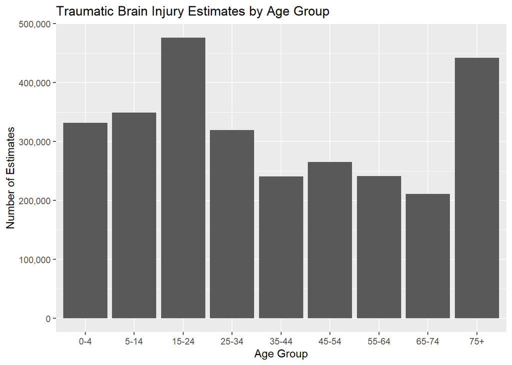

```r
# Filtering TBI Age table in order to get factored age group variables
tbiAgeFiltered <- tbiAge %>%
  filter(!age_group %in% c("Total","0-17")) %>%
  mutate(age_group = fct_relevel(age_group, c("0-4", "5-14", "15-24", "25-34", "35-44", "45-54", "55-64", "65-74", "75+")),
         type = fct_relevel(type, c("Emergency Department Visit", "Hospitalizations", "Deaths")))

# Traumatic Brain Injury Estimates by Age Group
tbiAgeFiltered %>%
  ggplot(aes(x=age_group, y=number_est)) +
  geom_col() +
  xlab("Age Group") +
  ylab("Number of Estimates") +
  labs(title = "Traumatic Brain Injury Estimates by Age Group") +
  scale_y_continuous(labels = scales::comma_format(scale = 1))
```

```r
# Traumatic Brain Injury Estimates by Injury Type
tbiAgeFiltered %>%
  group_by(injury_mechanism) %>%
  summarize(number_est = sum(number_est,na.rm=TRUE)) %>%
  mutate(percent = round(100 * number_est / sum(number_est),1))
```

```
## # A tibble: 7 × 3
##   injury_mechanism                                  number_est percent
##   <chr>                                                  <dbl>   <dbl>
## 1 Assault                                               232748     8.1
## 2 Intentional self-harm                                  22321     0.8
## 3 Motor Vehicle Crashes                                 403529    14
## 4 Other or no mechanism specified                       206984     7.2
## 5 Other unintentional injury, mechanism unspecified     189994     6.6
## 6 Unintentional Falls                                  1380082    48
## 7 Unintentionally struck by or against an object        441415    15.3
```

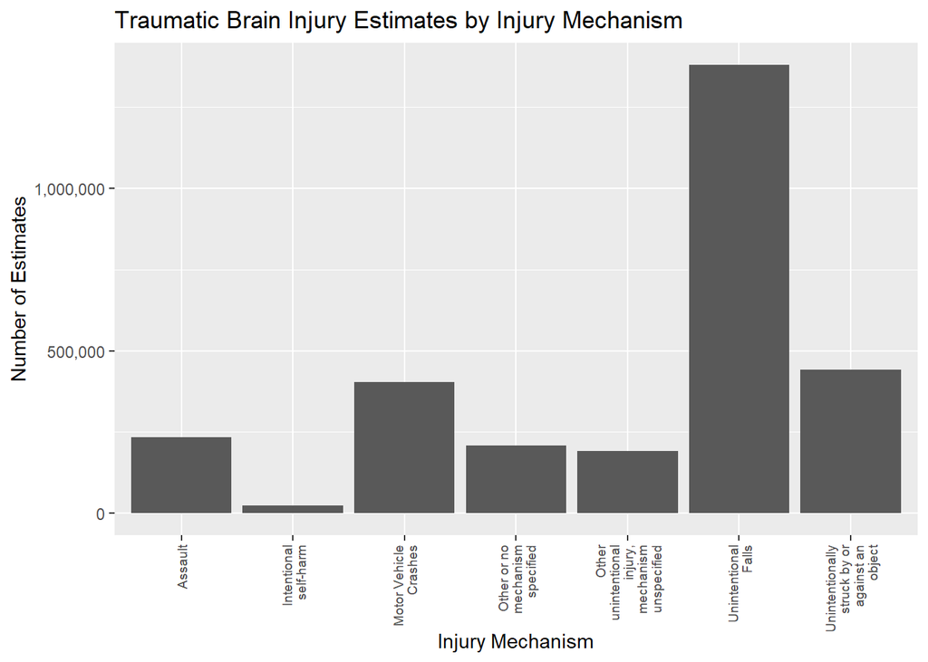

```r
tbiAgeFiltered$injury_mechanism_wrapped <- str_wrap(tbiAgeFiltered$injury_mechanism, width = 15)

tbiAgeFiltered %>%
  ggplot(aes(x=injury_mechanism_wrapped, y=number_est)) +
  geom_col() +
  xlab("Injury Mechanism") +
  ylab("Number of Estimates") +
  labs(title = "Traumatic Brain Injury Estimates by Injury Mechanism") +
  scale_y_continuous(labels = scales::comma_format(scale = 1)) +
  theme(axis.text.x = element_text(angle = 90, vjust = 0.5, hjust=1, size = 7))
```

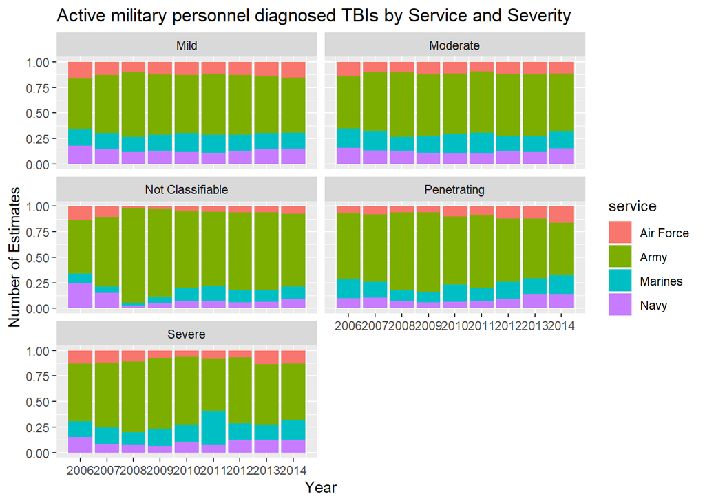

```r
# Active military personnel diagnosed TBIs by Service and Severity
tbiMilitary %>%
  filter(component == "Active") %>%
  ggplot(aes(x=year, y=diagnosed, fill=service)) +
  geom_bar(stat="identity", position="fill") +
  xlab("Year") +
  ylab("Number of Estimates") +
  labs(title = "Active military personnel diagnosed TBIs by Service and Severity") +
  facet_wrap(~severity, ncol = 2) +
  scale_x_continuous(breaks = seq(min(tbiMilitary$year), max(tbiMilitary$year), by = 1))
```

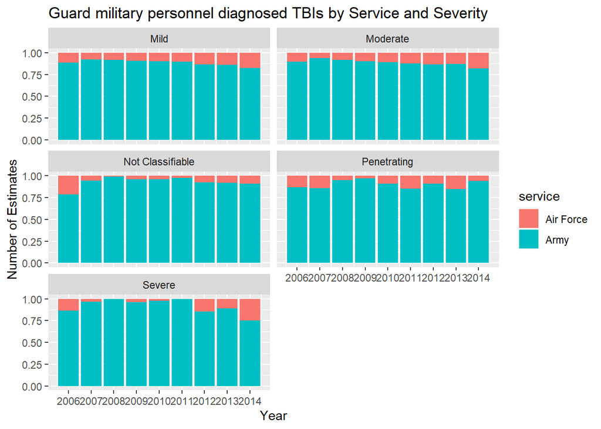

```r
# Guard military personnel diagnosed TBIs by Service and Severity
tbiMilitary %>%
  filter(component == "Guard") %>%
  ggplot(aes(x=year, y=diagnosed, fill=service)) +
  geom_bar(stat="identity", position="fill") +
  xlab("Year") +
  ylab("Number of Estimates") +
  labs(title = "Guard military personnel diagnosed TBIs by Service and Severity") +
  facet_wrap(~severity, ncol = 2) +
  scale_x_continuous(breaks = seq(min(tbiMilitary$year), max(tbiMilitary$year), by = 1))
```

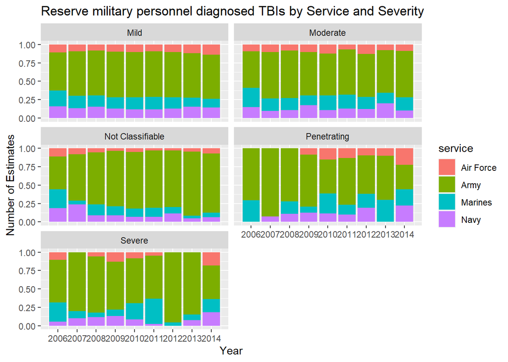

```r
# Reserve military personnel diagnosed TBIs by Service and Severity
tbiMilitary %>%
  filter(component == "Reserve") %>%
  ggplot(aes(x=year, y=diagnosed, fill=service)) +
  geom_bar(stat="identity", position="fill") +
  xlab("Year") +
  ylab("Number of Estimates") +
  labs(title = "Reserve military personnel diagnosed TBIs by Service and Severity") +
  facet_wrap(~severity, ncol = 2) +
  scale_x_continuous(breaks = seq(min(tbiMilitary$year), max(tbiMilitary$year), by = 1))
```

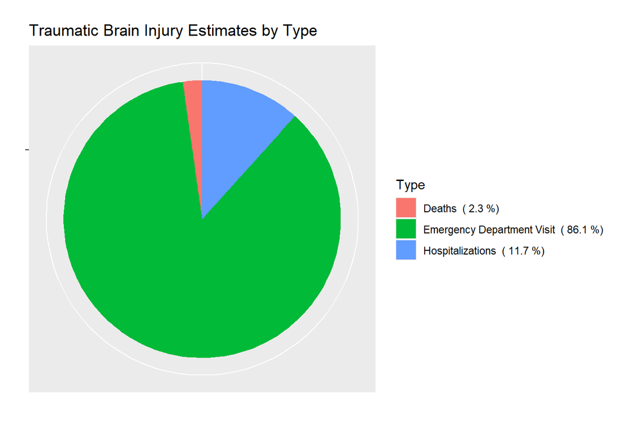

```r
# Traumatic Brain Injury Estimates by Outcome Type
tbiYearAgg <- tbiYear %>%
  group_by(type) %>%
  summarize(number_est = sum(number_est)) %>%
  mutate(percent = round(100 * number_est / sum(number_est),1))

tbiYearAgg %>%
  ggplot(aes(x="", y=number_est, fill=type)) +
  geom_bar(width=0.1, stat="identity", position="fill") +
  coord_polar(theta = "y") +
  scale_y_continuous(breaks = 1) +
  xlab("") +
  ylab("") +
  labs(title = "Traumatic Brain Injury Estimates by Type",
       fill = "Type") +
  scale_fill_discrete(labels = paste(tbiYearAgg$type, " (", tbiYearAgg$percent, "%)"))
```

The most at-risk group for TBI is 15-24 age group, closely followed by the elderly 75+. The age group 0-4 is also high risk, considering that they are only half the age range other age groups, yet are on a similar level to 5-14 and 25-34 year old group.

The most prevalent cause of injury is coming from Unintentional Falls (48.0%, n=1,380,082). The 2nd and 3rd most frequent are being Unintentionally Struck (15.3%, n=441,415) and Motor Vehicle Crashes (14.0%, n=403,529) respectively. Less frequent, but still relatively significant causes are Assaults (8.1%, n=232,748) and Other unintentional injuries (6.6%, n=189,994). The least frequent cause is Intentional Self-Harm (0.8%, n=22,321). Other and unclassified causes amount to 7.2% of the data (n=206,984).

The most affected group of TBI by far are Army personnel, followed by Marines and a tie between Air Force and Navy. Certain years were more critical to the Marines than others.

During the time frame of 2006-2014, 86.1% of the TBIs resulted in Emergency Department Visits, 11.7% in further Hospitalization, and 2.3% in Death.

# Model

Based on the preliminary EDA, I think meaningful questions can be asked regarding the predictor variables of injury mechanisms andage groups memberships for the rate of occurrences. For this, I’m going to use tbiAgeFiltered table as the base for model creation.

```r
cor(tbiAgeFiltered[sapply(tbiAgeFiltered,is.numeric)])
```

```
##            number_est  rate_est
## number_est  1.0000000 0.9424213
## rate_est    0.9424213 1.0000000
```

```r
tbiAgeModel <- lm(rate_est ~ injury_mechanism+type+age_group, data = tbiAgeFiltered)
summary(tbiAgeModel)
```

```
##
## Call:
## lm(formula = rate_est ~ injury_mechanism + type + age_group,
##     data = tbiAgeFiltered)
##
## Residuals:
##     Min      1Q  Median      3Q     Max
## -174.37  -50.17    7.41   35.18 1117.57
##
## Coefficients:
##                                                                   Estimate
## (Intercept)                                                        129.630
## injury_mechanismIntentional self-harm                              -18.430
## injury_mechanismMotor Vehicle Crashes                               17.270
## injury_mechanismOther or no mechanism specified                      3.196
## injury_mechanismOther unintentional injury, mechanism unspecified   -1.226
## injury_mechanismUnintentional Falls                                168.456
## injury_mechanismUnintentionally struck by or against an object      25.337
## typeHospitalizations                                              -110.519
## typeDeaths                                                        -123.616
## age_group5-14                                                      -39.052
## age_group15-24                                                     -27.743
## age_group25-34                                                     -44.395
## age_group35-44                                                     -51.071
## age_group45-54                                                     -50.257
## age_group55-64                                                     -50.657
## age_group65-74                                                     -41.305
## age_group75+                                                        26.848
##                                                                   Std. Error
## (Intercept)                                                           38.321
## injury_mechanismIntentional self-harm                                 34.776
## injury_mechanismMotor Vehicle Crashes                                 34.776
## injury_mechanismOther or no mechanism specified                       34.776
## injury_mechanismOther unintentional injury, mechanism unspecified     34.776
## injury_mechanismUnintentional Falls                                   34.776
## injury_mechanismUnintentionally struck by or against an object        34.776
## typeHospitalizations                                                  22.766
## typeDeaths                                                            22.766
## age_group5-14                                                         39.432
## age_group15-24                                                        39.432
```

[output cut: 33 more lines]

```
## typeDeaths                                                        1.90e-07 ***
## age_group5-14                                                     0.323380
## age_group15-24                                                    0.482654
## age_group25-34                                                    0.261787
## age_group35-44                                                    0.196992
## age_group45-54                                                    0.204193
## age_group55-64                                                    0.200632
## age_group65-74                                                    0.296339
## age_group75+                                                      0.496874
## ---
## Signif. codes:  0 '***' 0.001 '**' 0.01 '*' 0.05 '.' 0.1 ' ' 1
##
## Residual standard error: 127.8 on 172 degrees of freedom
## Multiple R-squared:  0.326,  Adjusted R-squared:  0.2633
## F-statistic:   5.2 on 16 and 172 DF,  p-value: 8.111e-09
```

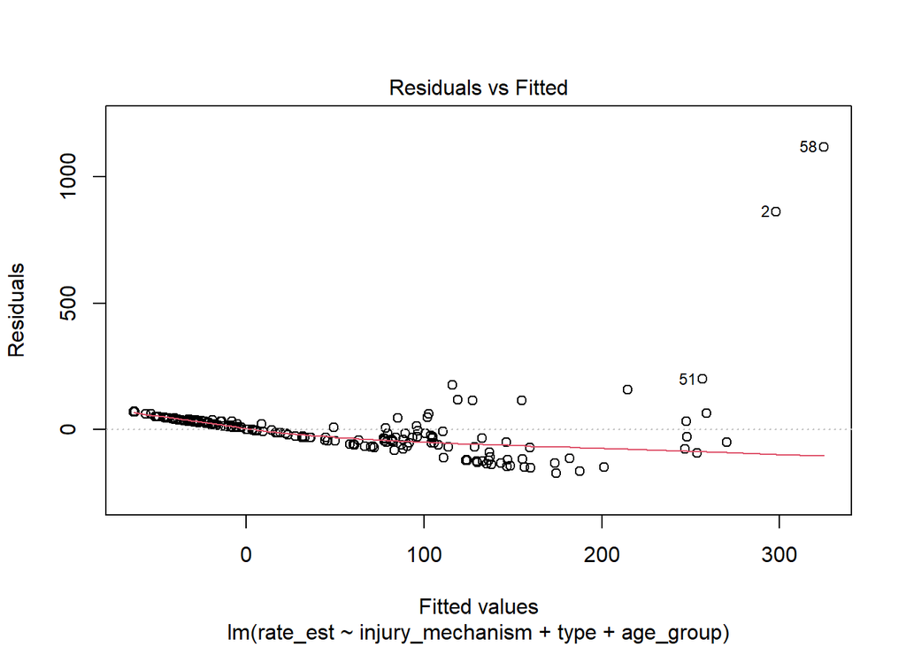

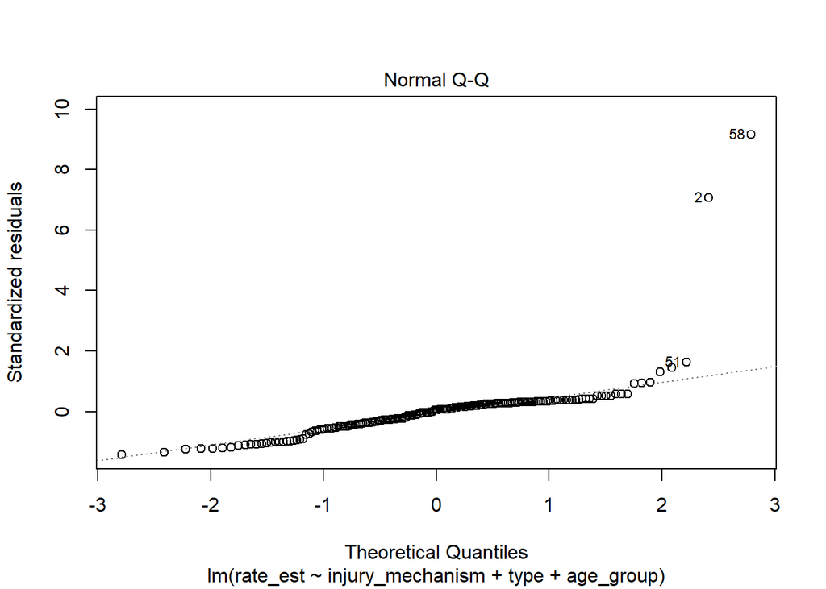

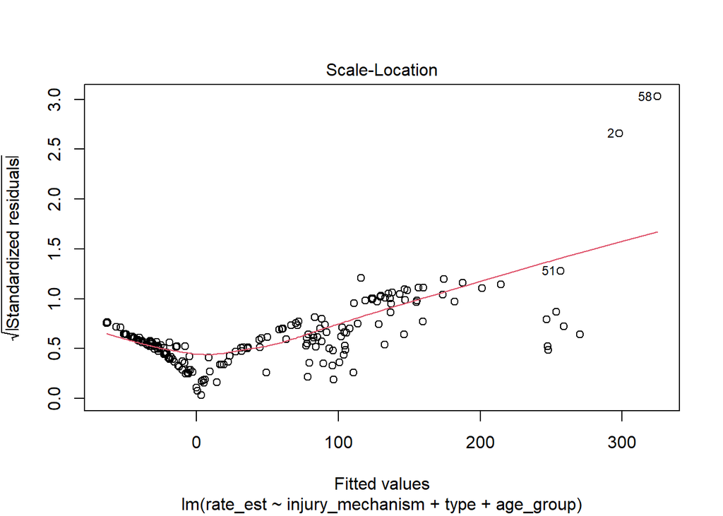

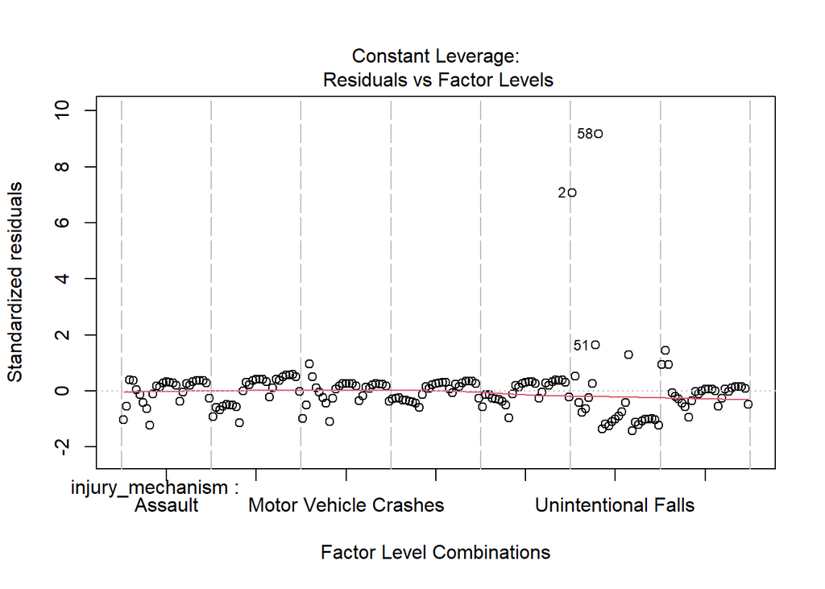

```r
plot(tbiAgeModel)
```

```r
# Removing outliers #58, #2 and #51
tbiAgeFilteredNoOutliers <- tbiAgeFiltered %>% slice(-58,-2,-51)

tbiAgeNoOutliersModel <- lm(rate_est ~ injury_mechanism+type+age_group, data = tbiAgeFilteredNoOutliers)
summary(tbiAgeNoOutliersModel)
```

```
##
## Call:
## lm(formula = rate_est ~ injury_mechanism + type + age_group,
##     data = tbiAgeFilteredNoOutliers)
##
## Residuals:
##     Min      1Q  Median      3Q     Max
## -81.058 -24.332  -1.477  15.906 290.119
##
## Coefficients:
##                                                                   Estimate
## (Intercept)                                                         66.922
## injury_mechanismIntentional self-harm                              -18.430
## injury_mechanismMotor Vehicle Crashes                               17.270
## injury_mechanismOther or no mechanism specified                      3.196
## injury_mechanismOther unintentional injury, mechanism unspecified   -1.226
## injury_mechanismUnintentional Falls                                 70.644
## injury_mechanismUnintentionally struck by or against an object      25.337
## typeHospitalizations                                               -68.600
## typeDeaths                                                         -81.697
## age_group5-14                                                        9.683
## age_group15-24                                                      20.992
## age_group25-34                                                       4.340
## age_group35-44                                                      -2.336
## age_group45-54                                                      -1.522
## age_group55-64                                                      -1.922
## age_group65-74                                                      -8.125
## age_group75+                                                        14.115
##                                                                   Std. Error
## (Intercept)                                                           15.166
## injury_mechanismIntentional self-harm                                 13.524
## injury_mechanismMotor Vehicle Crashes                                 13.524
## injury_mechanismOther or no mechanism specified                       13.524
## injury_mechanismOther unintentional injury, mechanism unspecified     13.524
## injury_mechanismUnintentional Falls                                   13.971
## injury_mechanismUnintentionally struck by or against an object        13.524
## typeHospitalizations                                                   8.980
## typeDeaths                                                             8.980
## age_group5-14                                                         15.535
## age_group15-24                                                        15.535
```

[output cut: 33 more lines]

```
## typeDeaths                                                        2.49e-16 ***
## age_group5-14                                                       0.5339
## age_group15-24                                                      0.1784
## age_group25-34                                                      0.7803
## age_group35-44                                                      0.8806
## age_group45-54                                                      0.9221
## age_group55-64                                                      0.9017
## age_group65-74                                                      0.6058
## age_group75+                                                        0.3703
## ---
## Signif. codes:  0 '***' 0.001 '**' 0.01 '*' 0.05 '.' 0.1 ' ' 1
##
## Residual standard error: 49.69 on 169 degrees of freedom
## Multiple R-squared:  0.4609, Adjusted R-squared:  0.4099
## F-statistic: 9.031 on 16 and 169 DF,  p-value: 8.698e-16
```

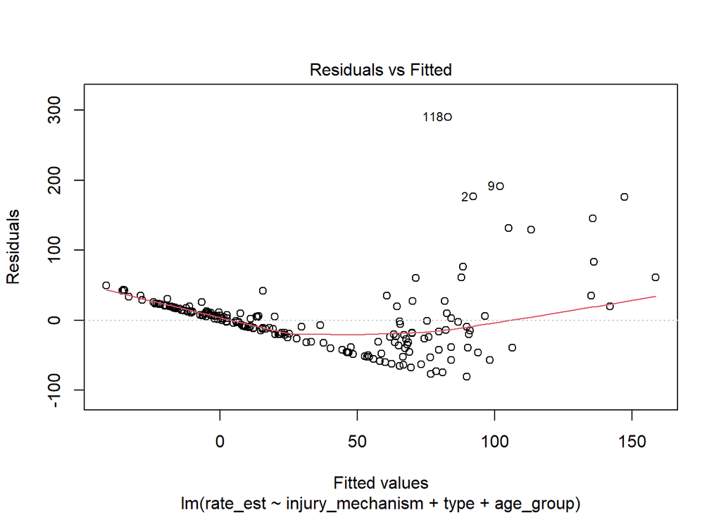

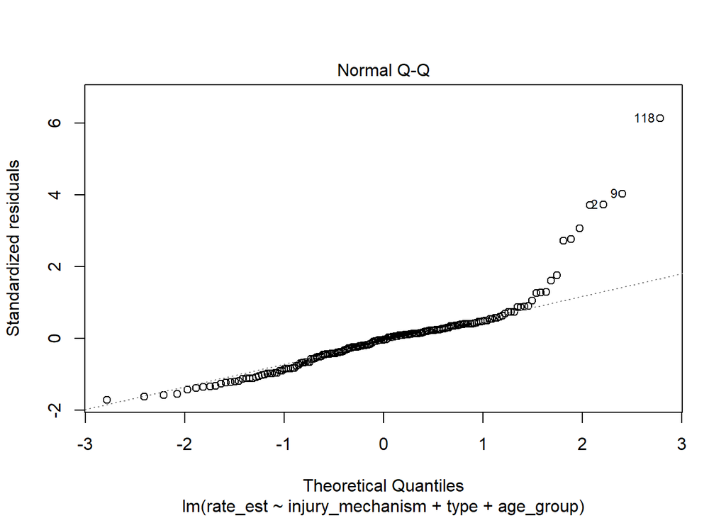

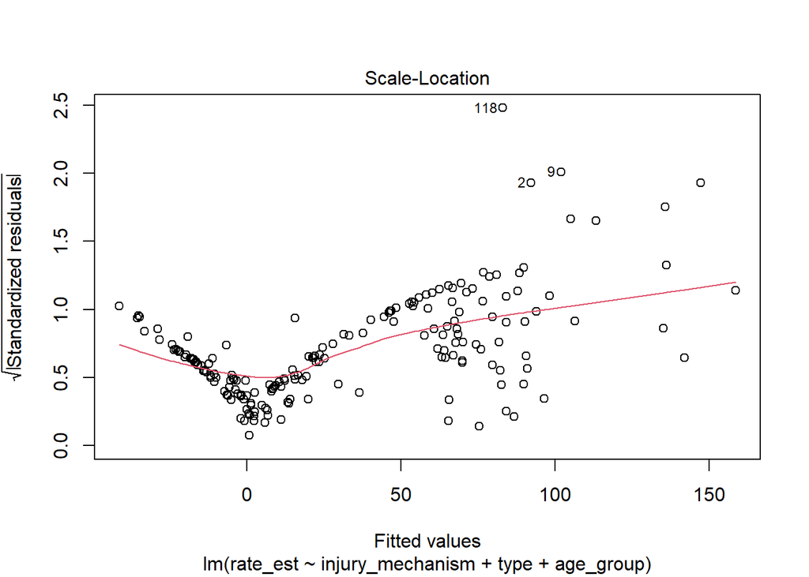

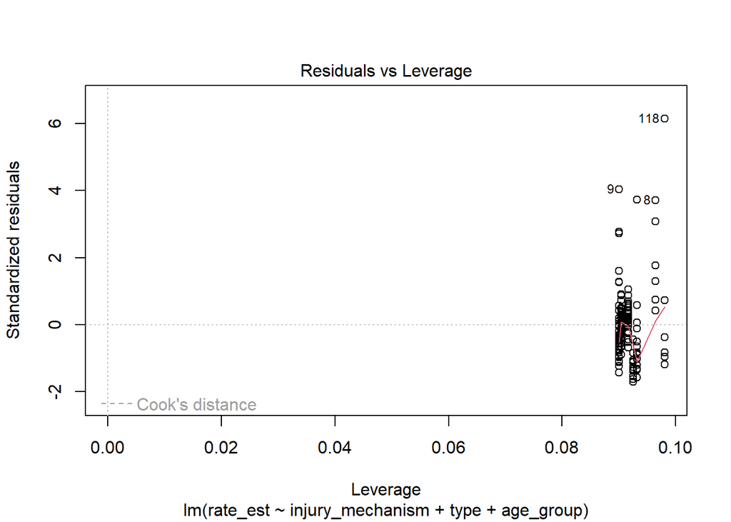

```r
plot(tbiAgeNoOutliersModel)
```

```r
# Removing outliers #118, #2 and #9
tbiAgeFilteredNoOutliers2nd <- tbiAgeFilteredNoOutliers %>% slice(-118,-2,-9)

tbiAgeNoOutliersModel2nd <- lm(rate_est ~ injury_mechanism+type+age_group, data = tbiAgeFilteredNoOutliers2nd)
summary(tbiAgeNoOutliersModel2nd)
```

```
##
## Call:
## lm(formula = rate_est ~ injury_mechanism + type + age_group,
##     data = tbiAgeFilteredNoOutliers2nd)
##
## Residuals:
##     Min      1Q  Median      3Q     Max
## -70.878 -22.413   1.055  12.325 199.675
##
## Coefficients:
##                                                                   Estimate
## (Intercept)                                                         56.927
## injury_mechanismIntentional self-harm                              -18.430
## injury_mechanismMotor Vehicle Crashes                               17.270
## injury_mechanismOther or no mechanism specified                      3.196
## injury_mechanismOther unintentional injury, mechanism unspecified   -1.226
## injury_mechanismUnintentional Falls                                 56.346
## injury_mechanismUnintentionally struck by or against an object       9.836
## typeHospitalizations                                               -65.908
## typeDeaths                                                         -73.965
## age_group5-14                                                       10.151
## age_group15-24                                                      31.770
## age_group25-34                                                      15.117
## age_group35-44                                                       8.441
## age_group45-54                                                       9.255
## age_group55-64                                                       8.855
## age_group65-74                                                       1.977
## age_group75+                                                         8.342
##                                                                   Std. Error
## (Intercept)                                                           12.026
## injury_mechanismIntentional self-harm                                 10.521
## injury_mechanismMotor Vehicle Crashes                                 10.521
## injury_mechanismOther or no mechanism specified                       10.521
## injury_mechanismOther unintentional injury, mechanism unspecified     10.521
## injury_mechanismUnintentional Falls                                   11.008
## injury_mechanismUnintentionally struck by or against an object        10.743
## typeHospitalizations                                                   7.076
## typeDeaths                                                             7.055
## age_group5-14                                                         12.392
## age_group15-24                                                        12.258
```

[output cut: 33 more lines]

```
## typeDeaths                                                         < 2e-16 ***
## age_group5-14                                                       0.4139
## age_group15-24                                                      0.0104 *
## age_group25-34                                                      0.2192
## age_group35-44                                                      0.4920
## age_group45-54                                                      0.4513
## age_group55-64                                                      0.4710
## age_group65-74                                                      0.8734
## age_group75+                                                        0.5075
## ---
## Signif. codes:  0 '***' 0.001 '**' 0.01 '*' 0.05 '.' 0.1 ' ' 1
##
## Residual standard error: 38.65 on 166 degrees of freedom
## Multiple R-squared:  0.5327, Adjusted R-squared:  0.4877
## F-statistic: 11.83 on 16 and 166 DF,  p-value: < 2.2e-16
```

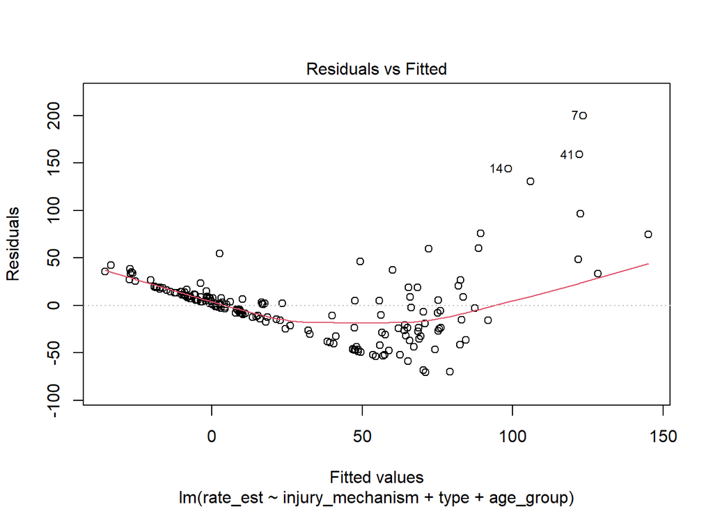

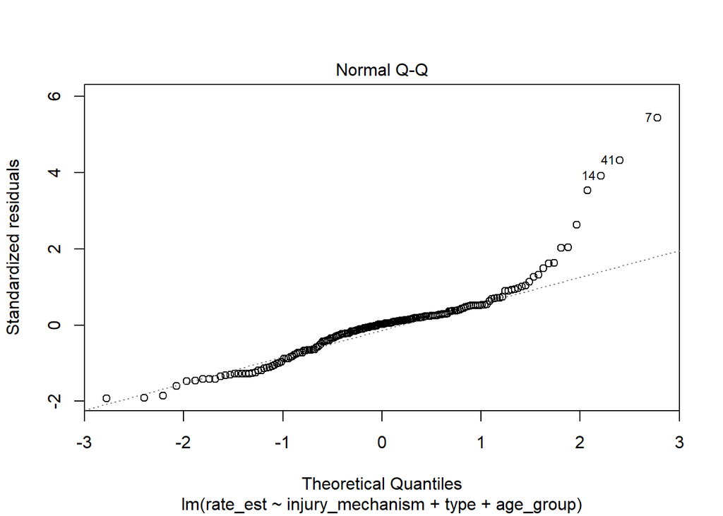

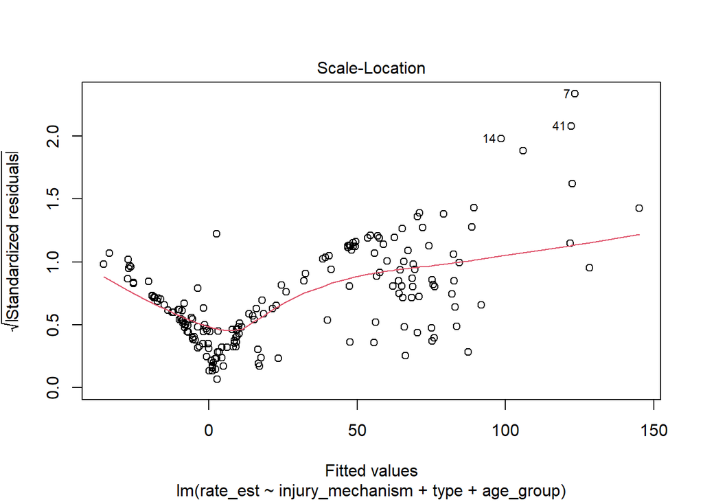

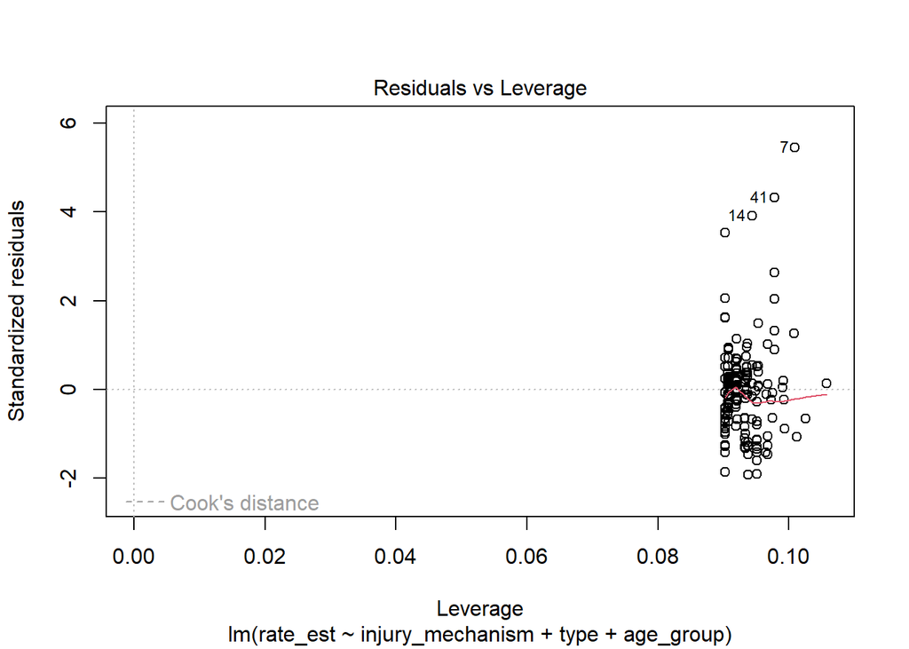

```r
plot(tbiAgeNoOutliersModel2nd)
```

```r
# Removing outliers #7, #41 and #14
tbiAgeFilteredNoOutliers3rd <- tbiAgeFilteredNoOutliers2nd %>% slice(-7,-41,-14)

tbiAgeNoOutliersModel3rd <- lm(rate_est ~ injury_mechanism+type+age_group, data = tbiAgeFilteredNoOutliers3rd)
summary(tbiAgeNoOutliersModel3rd)
```

```
##
## Call:
## lm(formula = rate_est ~ injury_mechanism + type + age_group,
##     data = tbiAgeFilteredNoOutliers3rd)
##
## Residuals:
##    Min     1Q Median     3Q    Max
## -56.98 -17.23  -0.62  10.08 141.72
##
## Coefficients:
##                                                                   Estimate
## (Intercept)                                                        51.6373
## injury_mechanismIntentional self-harm                             -18.4296
## injury_mechanismMotor Vehicle Crashes                              17.2704
## injury_mechanismOther or no mechanism specified                     3.1963
## injury_mechanismOther unintentional injury, mechanism unspecified  -1.2259
## injury_mechanismUnintentional Falls                                37.4594
## injury_mechanismUnintentionally struck by or against an object      2.4802
## typeHospitalizations                                              -55.0863
## typeDeaths                                                        -62.9310
## age_group5-14                                                      -0.3579
## age_group15-24                                                     25.7702
## age_group25-34                                                     16.8708
## age_group35-44                                                     10.1946
## age_group45-54                                                     11.0088
## age_group55-64                                                      1.5491
## age_group65-74                                                      2.6091
## age_group75+                                                        8.3049
##                                                                   Std. Error
## (Intercept)                                                           9.3747
## injury_mechanismIntentional self-harm                                 8.1890
## injury_mechanismMotor Vehicle Crashes                                 8.1890
## injury_mechanismOther or no mechanism specified                       8.1890
## injury_mechanismOther unintentional injury, mechanism unspecified     8.1890
## injury_mechanismUnintentional Falls                                   8.8090
## injury_mechanismUnintentionally struck by or against an object        8.4613
## typeHospitalizations                                                  5.6042
## typeDeaths                                                            5.5911
## age_group5-14                                                         9.7619
## age_group15-24                                                        9.6465
```

[output cut: 33 more lines]

```
## typeDeaths                                                         < 2e-16 ***
## age_group5-14                                                      0.97080
## age_group15-24                                                     0.00832 **
## age_group25-34                                                     0.07894 .
## age_group35-44                                                     0.28695
## age_group45-54                                                     0.25033
## age_group55-64                                                     0.87260
## age_group65-74                                                     0.78712
## age_group75+                                                       0.39692
## ---
## Signif. codes:  0 '***' 0.001 '**' 0.01 '*' 0.05 '.' 0.1 ' ' 1
##
## Residual standard error: 30.09 on 163 degrees of freedom
## Multiple R-squared:  0.5541, Adjusted R-squared:  0.5103
## F-statistic: 12.66 on 16 and 163 DF,  p-value: < 2.2e-16
```

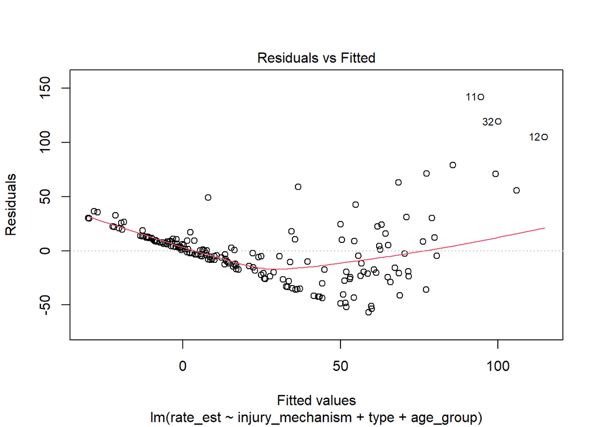

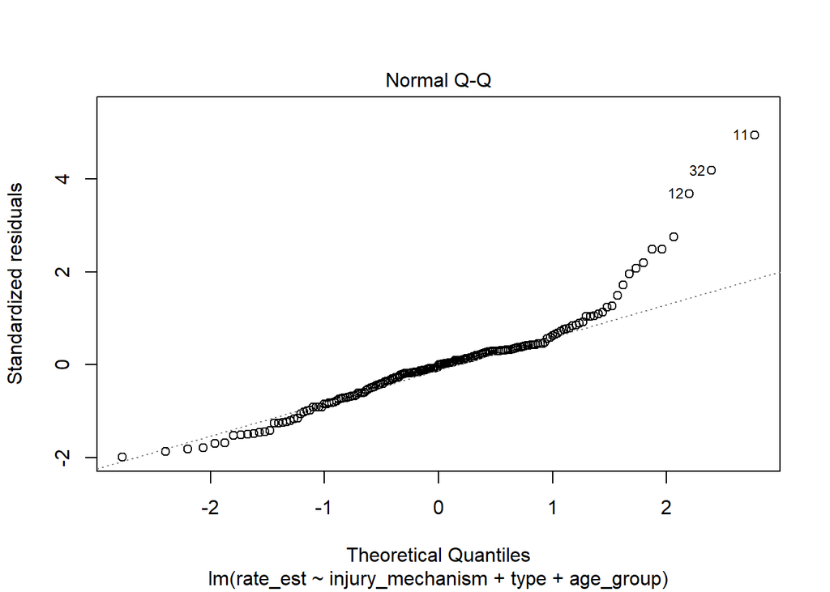

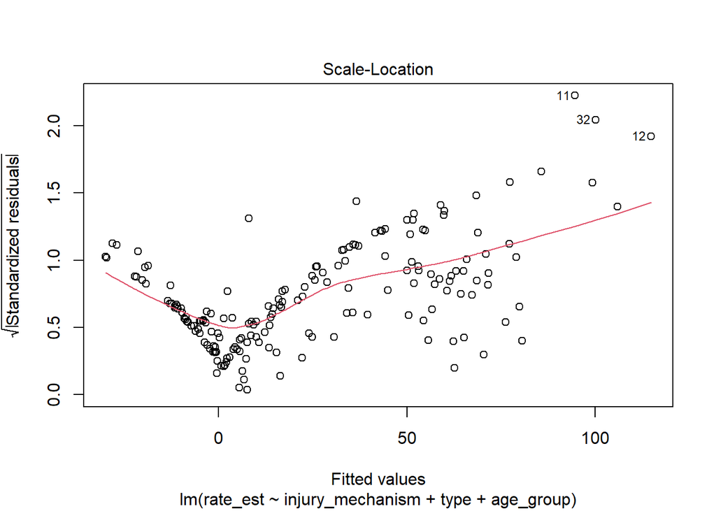

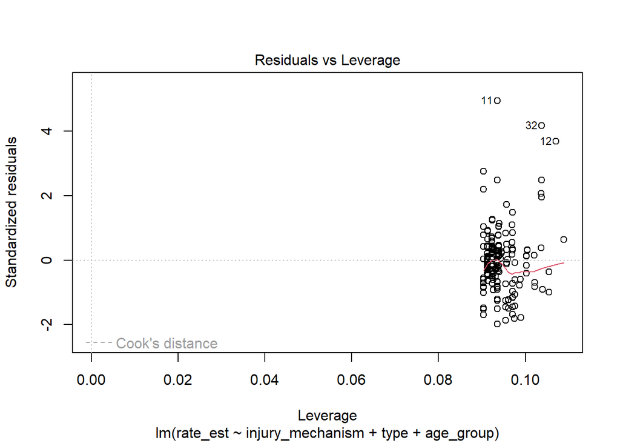

```r
plot(tbiAgeNoOutliersModel3rd)
```

```r
# Removing outliers #12, #32 and #11
tbiAgeFilteredNoOutliers4th <- tbiAgeFilteredNoOutliers3rd %>% slice(-12,-32,-11)

tbiAgeNoOutliersModel4th <- lm(rate_est ~ injury_mechanism+type+age_group, data = tbiAgeFilteredNoOutliers4th)
summary(tbiAgeNoOutliersModel4th)
```

```
##
## Call:
## lm(formula = rate_est ~ injury_mechanism + type + age_group,
##     data = tbiAgeFilteredNoOutliers4th)
##
## Residuals:
##     Min      1Q  Median      3Q     Max
## -49.331 -12.131  -1.923   7.233  89.648
##
## Coefficients:
##                                                                   Estimate
## (Intercept)                                                        47.6433
## injury_mechanismIntentional self-harm                             -18.4296
## injury_mechanismMotor Vehicle Crashes                              11.1174
## injury_mechanismOther or no mechanism specified                     3.1963
## injury_mechanismOther unintentional injury, mechanism unspecified  -1.2259
## injury_mechanismUnintentional Falls                                23.4100
## injury_mechanismUnintentionally struck by or against an object      1.3867
## typeHospitalizations                                              -46.2590
## typeDeaths                                                        -53.9539
## age_group5-14                                                      -0.3579
## age_group15-24                                                     11.5089
## age_group25-34                                                     17.9722
## age_group35-44                                                     11.2960
## age_group45-54                                                      5.3085
## age_group55-64                                                      1.8035
## age_group65-74                                                      2.8635
## age_group75+                                                        8.0876
##                                                                   Std. Error
## (Intercept)                                                           7.5090
## injury_mechanismIntentional self-harm                                 6.5486
## injury_mechanismMotor Vehicle Crashes                                 6.6155
## injury_mechanismOther or no mechanism specified                       6.5486
## injury_mechanismOther unintentional injury, mechanism unspecified     6.5486
## injury_mechanismUnintentional Falls                                   7.2829
## injury_mechanismUnintentionally struck by or against an object        6.7675
## typeHospitalizations                                                  4.5754
## typeDeaths                                                            4.5689
## age_group5-14                                                         7.8065
## age_group15-24                                                        7.9195
```

[output cut: 33 more lines]

```
## typeDeaths                                                         < 2e-16 ***
## age_group5-14                                                      0.96349
## age_group15-24                                                     0.14811
## age_group25-34                                                     0.01975 *
## age_group35-44                                                     0.14083
## age_group45-54                                                     0.49232
## age_group55-64                                                     0.81543
## age_group65-74                                                     0.71096
## age_group75+                                                       0.30255
## ---
## Signif. codes:  0 '***' 0.001 '**' 0.01 '*' 0.05 '.' 0.1 ' ' 1
##
## Residual standard error: 24.06 on 160 degrees of freedom
## Multiple R-squared:  0.5534, Adjusted R-squared:  0.5088
## F-statistic: 12.39 on 16 and 160 DF,  p-value: < 2.2e-16
```

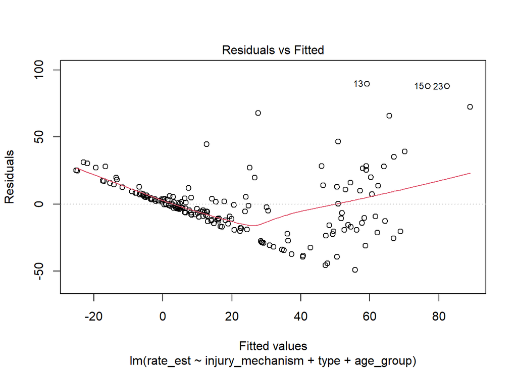

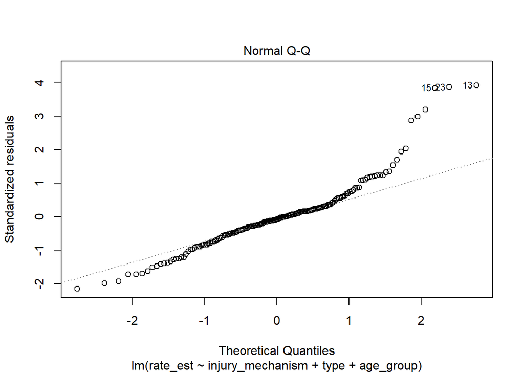

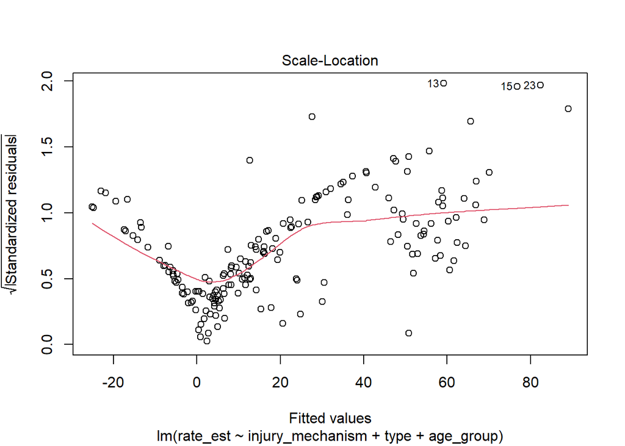

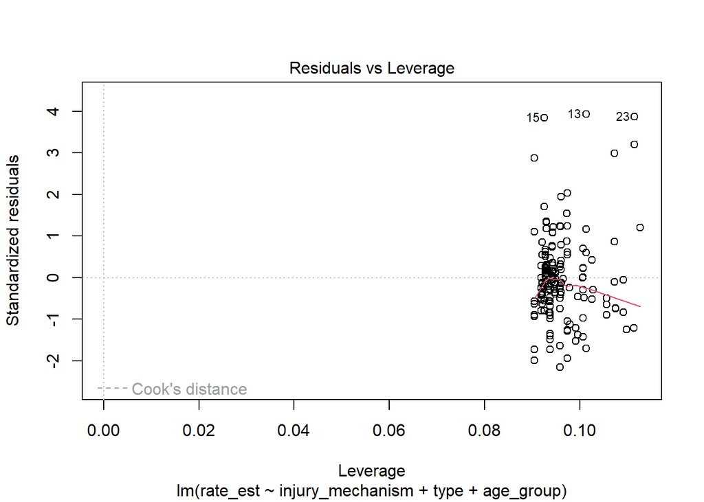

```r
plot(tbiAgeNoOutliersModel4th)
```

```r
# Removing outliers #15, #23 and #13
tbiAgeFilteredNoOutliers5th <- tbiAgeFilteredNoOutliers4th %>% slice(-15,-23,-13)

tbiAgeNoOutliersModel5th <- lm(rate_est ~ injury_mechanism+type+age_group, data = tbiAgeFilteredNoOutliers5th)
summary(tbiAgeNoOutliersModel5th)
```

```
##
## Call:
## lm(formula = rate_est ~ injury_mechanism + type + age_group,
##     data = tbiAgeFilteredNoOutliers5th)
##
## Residuals:
##     Min      1Q  Median      3Q     Max
## -42.896  -9.562  -2.226   5.229  85.787
##
## Coefficients:
##                                                                   Estimate
## (Intercept)                                                        41.1831
## injury_mechanismIntentional self-harm                             -14.6458
## injury_mechanismMotor Vehicle Crashes                              10.7571
## injury_mechanismOther or no mechanism specified                     6.9801
## injury_mechanismOther unintentional injury, mechanism unspecified   2.5579
## injury_mechanismUnintentional Falls                                20.7841
## injury_mechanismUnintentionally struck by or against an object      4.5837
## typeHospitalizations                                              -39.9502
## typeDeaths                                                        -47.6015
## age_group5-14                                                      -0.3579
## age_group15-24                                                      5.4543
## age_group25-34                                                     13.8453
## age_group35-44                                                      7.0667
## age_group45-54                                                      5.4717
## age_group55-64                                                      1.9667
## age_group65-74                                                      3.0267
## age_group75+                                                        8.1132
##                                                                   Std. Error
## (Intercept)                                                           6.4736
## injury_mechanismIntentional self-harm                                 5.6317
## injury_mechanismMotor Vehicle Crashes                                 5.7406
## injury_mechanismOther or no mechanism specified                       5.6317
## injury_mechanismOther unintentional injury, mechanism unspecified     5.6317
## injury_mechanismUnintentional Falls                                   6.3551
## injury_mechanismUnintentionally struck by or against an object        5.8067
## typeHospitalizations                                                  3.9750
## typeDeaths                                                            3.9710
## age_group5-14                                                         6.6453
## age_group15-24                                                        6.8502
```

[output cut: 33 more lines]

```
## typeDeaths                                                         < 2e-16 ***
## age_group5-14                                                      0.95712
## age_group15-24                                                     0.42710
## age_group25-34                                                     0.03681 *
## age_group35-44                                                     0.28348
## age_group45-54                                                     0.40594
## age_group55-64                                                     0.76495
## age_group65-74                                                     0.64548
## age_group75+                                                       0.22472
## ---
## Signif. codes:  0 '***' 0.001 '**' 0.01 '*' 0.05 '.' 0.1 ' ' 1
##
## Residual standard error: 20.48 on 157 degrees of freedom
## Multiple R-squared:  0.5515, Adjusted R-squared:  0.5057
## F-statistic: 12.06 on 16 and 157 DF,  p-value: < 2.2e-16
```

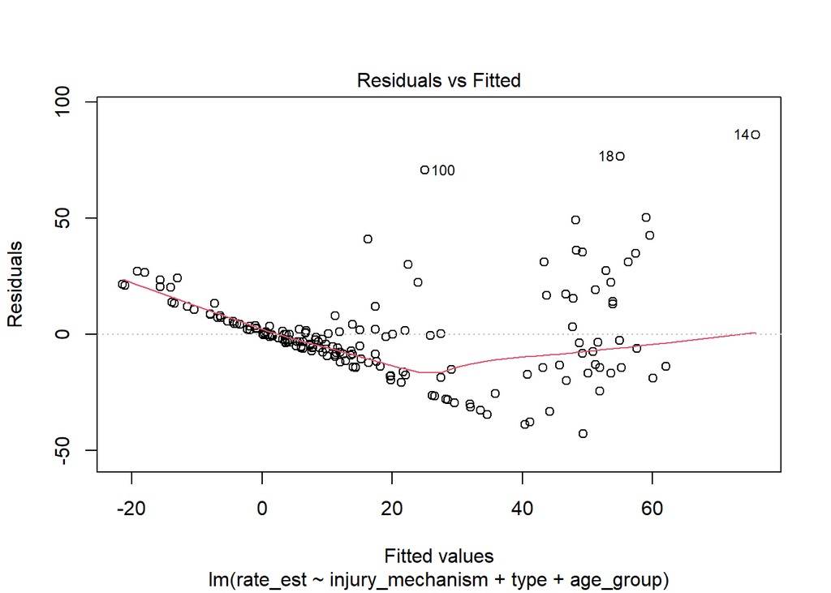

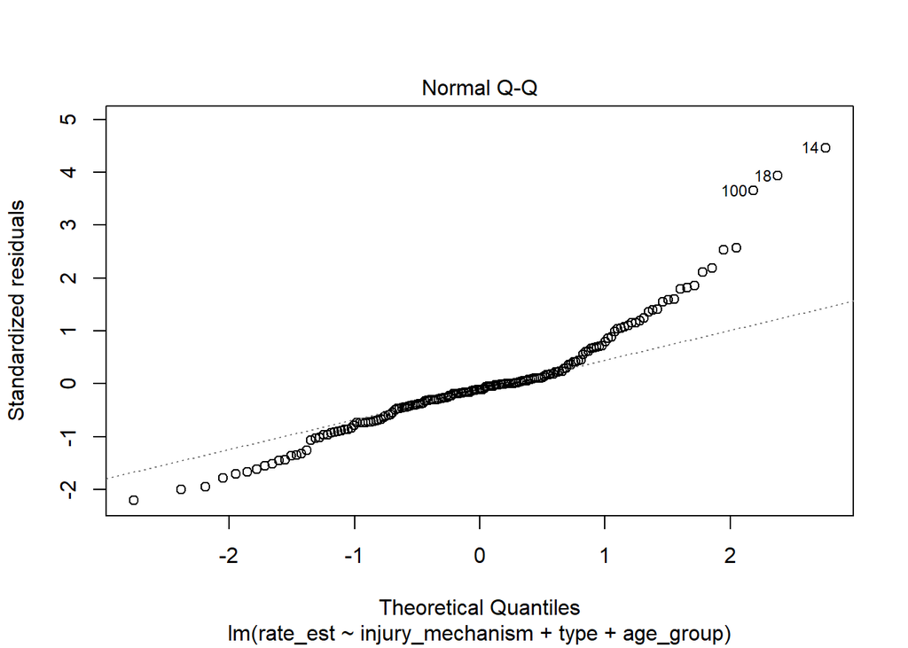

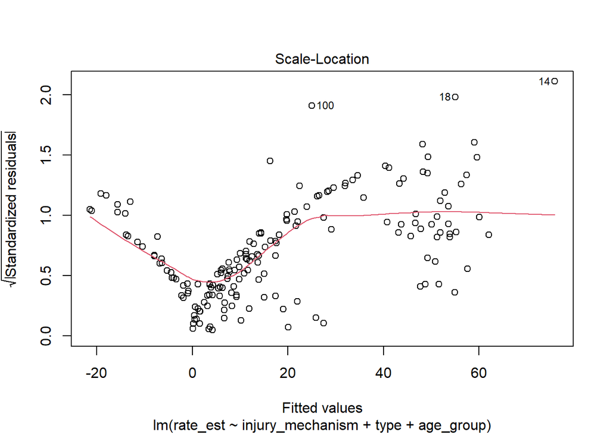

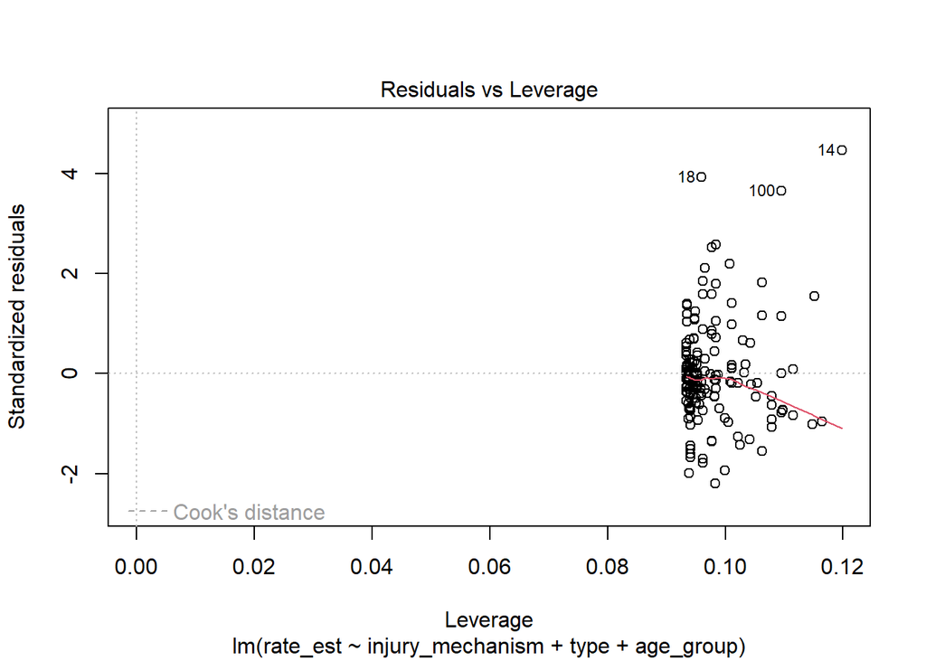

```r
plot(tbiAgeNoOutliersModel5th)
```

```r
# Removing outliers #100, #18 and #14
tbiAgeFilteredNoOutliers6th <- tbiAgeFilteredNoOutliers5th %>% slice(-100,-18,-14)

tbiAgeNoOutliersModel6th <- lm(rate_est ~ injury_mechanism+type+age_group, data = tbiAgeFilteredNoOutliers6th)
summary(tbiAgeNoOutliersModel6th)
```

```
##
## Call:
## lm(formula = rate_est ~ injury_mechanism + type + age_group,
##     data = tbiAgeFilteredNoOutliers6th)
##
## Residuals:
##     Min      1Q  Median      3Q     Max
## -37.474  -9.113  -3.360   5.863  53.564
##
## Coefficients:
##                                                                   Estimate
## (Intercept)                                                        36.1541
## injury_mechanismIntentional self-harm                             -11.0770
## injury_mechanismMotor Vehicle Crashes                              13.8200
## injury_mechanismOther or no mechanism specified                    10.5489
## injury_mechanismOther unintentional injury, mechanism unspecified   6.1267
## injury_mechanismUnintentional Falls                                12.8950
## injury_mechanismUnintentionally struck by or against an object      7.9528
## typeHospitalizations                                              -36.1708
## typeDeaths                                                        -42.3405
## age_group5-14                                                      -0.3579
## age_group15-24                                                      5.0428
## age_group25-34                                                      4.5290
## age_group35-44                                                      7.1497
## age_group45-54                                                      5.5547
## age_group55-64                                                      2.0497
## age_group65-74                                                     -1.0805
## age_group75+                                                        7.7195
##                                                                   Std. Error
## (Intercept)                                                           5.3984
## injury_mechanismIntentional self-harm                                 4.6843
## injury_mechanismMotor Vehicle Crashes                                 4.7659
## injury_mechanismOther or no mechanism specified                       4.6843
## injury_mechanismOther unintentional injury, mechanism unspecified     4.6843
## injury_mechanismUnintentional Falls                                   5.4728
## injury_mechanismUnintentionally struck by or against an object        4.8237
## typeHospitalizations                                                  3.3313
## typeDeaths                                                            3.3282
## age_group5-14                                                         5.4668
## age_group15-24                                                        5.6358
```

[output cut: 33 more lines]

```
## typeDeaths                                                         < 2e-16 ***
## age_group5-14                                                      0.94789
## age_group15-24                                                     0.37230
## age_group25-34                                                     0.41593
## age_group35-44                                                     0.18761
## age_group45-54                                                     0.30542
## age_group55-64                                                     0.70489
## age_group65-74                                                     0.84386
## age_group75+                                                       0.16067
## ---
## Signif. codes:  0 '***' 0.001 '**' 0.01 '*' 0.05 '.' 0.1 ' ' 1
##
## Residual standard error: 16.85 on 154 degrees of freedom
## Multiple R-squared:  0.5906, Adjusted R-squared:  0.5481
## F-statistic: 13.88 on 16 and 154 DF,  p-value: < 2.2e-16
```

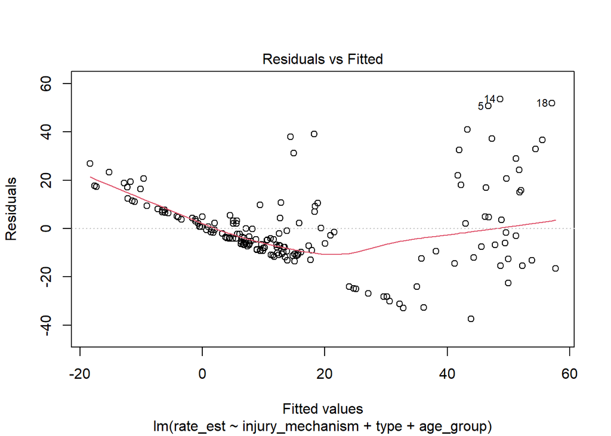

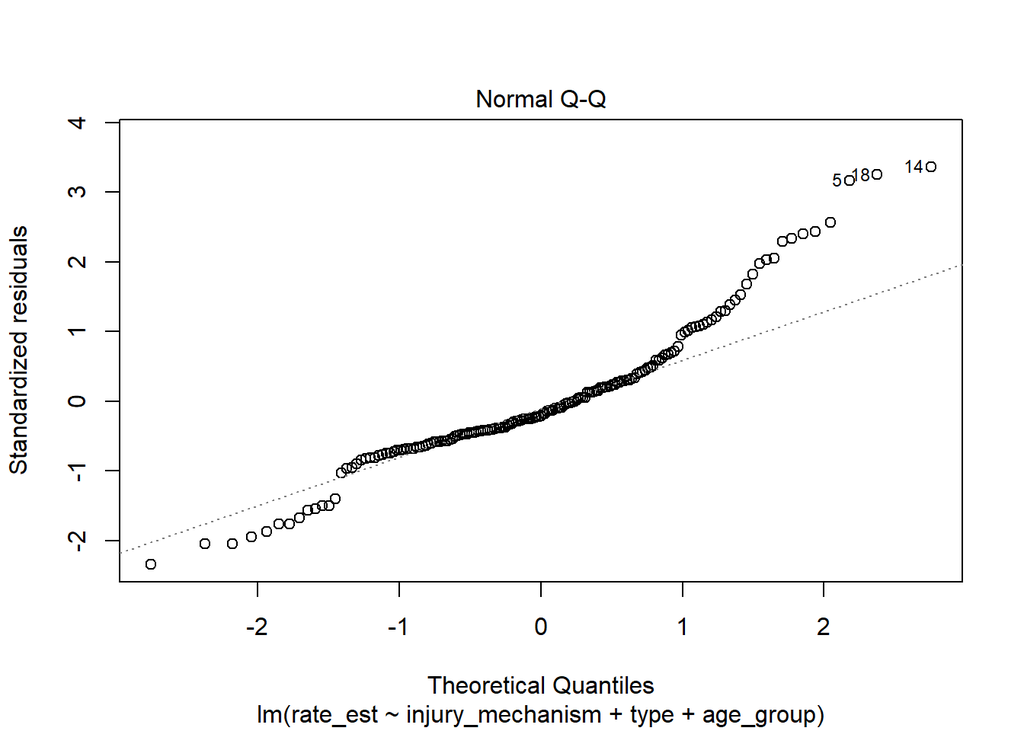

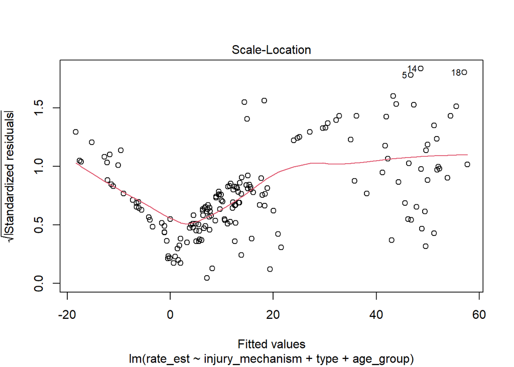

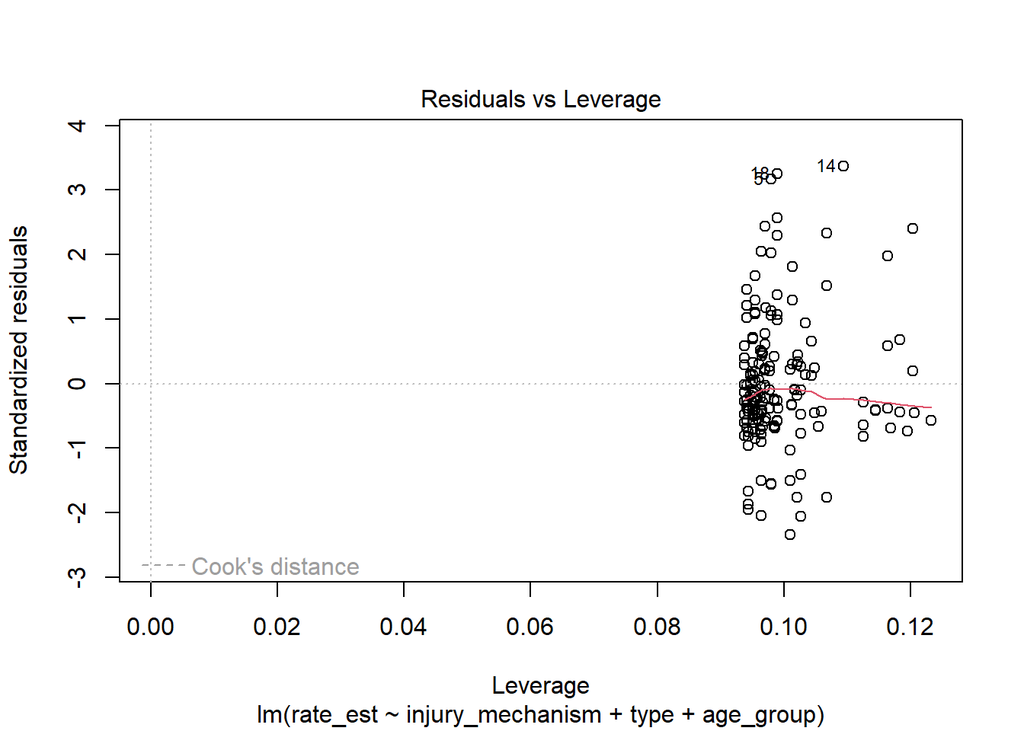

```r
plot(tbiAgeNoOutliersModel6th)
```

```r
# Removing outliers #5, #18 and #14
tbiAgeFilteredNoOutliers7th <- tbiAgeFilteredNoOutliers6th %>% slice(-5,-18,-14)

tbiAgeNoOutliersModel7th <- lm(rate_est ~ injury_mechanism+type+age_group, data = tbiAgeFilteredNoOutliers7th)
summary(tbiAgeNoOutliersModel7th)
```

```
##
## Call:
## lm(formula = rate_est ~ injury_mechanism + type + age_group,
##     data = tbiAgeFilteredNoOutliers7th)
##
## Residuals:
##     Min      1Q  Median      3Q     Max
## -35.768  -7.789  -2.857   5.844  45.728
##
## Coefficients:
##                                                                   Estimate
## (Intercept)                                                         31.113
## injury_mechanismIntentional self-harm                              -10.784
## injury_mechanismMotor Vehicle Crashes                               11.457
## injury_mechanismOther or no mechanism specified                      8.710
## injury_mechanismOther unintentional injury, mechanism unspecified    6.420
## injury_mechanismUnintentional Falls                                 12.013
## injury_mechanismUnintentionally struck by or against an object       5.317
## typeHospitalizations                                               -32.142
## typeDeaths                                                         -38.358
## age_group5-14                                                        2.672
## age_group15-24                                                       7.698
## age_group25-34                                                       4.033
## age_group35-44                                                       7.459
## age_group45-54                                                       8.817
## age_group55-64                                                       5.312
## age_group65-74                                                       2.254
## age_group75+                                                        11.054
##                                                                   Std. Error
## (Intercept)                                                            4.945
## injury_mechanismIntentional self-harm                                  4.198
## injury_mechanismMotor Vehicle Crashes                                  4.318
## injury_mechanismOther or no mechanism specified                        4.237
## injury_mechanismOther unintentional injury, mechanism unspecified      4.198
## injury_mechanismUnintentional Falls                                    4.906
## injury_mechanismUnintentionally struck by or against an object         4.370
## typeHospitalizations                                                   3.051
## typeDeaths                                                             3.047
## age_group5-14                                                          4.970
## age_group15-24                                                         5.117
```

[output cut: 33 more lines]

```
## typeDeaths                                                         < 2e-16 ***
## age_group5-14                                                      0.59156
## age_group15-24                                                     0.13456
## age_group25-34                                                     0.43182
## age_group35-44                                                     0.13595
## age_group45-54                                                     0.07478 .
## age_group55-64                                                     0.28143
## age_group65-74                                                     0.65153
## age_group75+                                                       0.02797 *
## ---
## Signif. codes:  0 '***' 0.001 '**' 0.01 '*' 0.05 '.' 0.1 ' ' 1
##
## Residual standard error: 15.1 on 151 degrees of freedom
## Multiple R-squared:  0.5893, Adjusted R-squared:  0.5457
## F-statistic: 13.54 on 16 and 151 DF,  p-value: < 2.2e-16
```

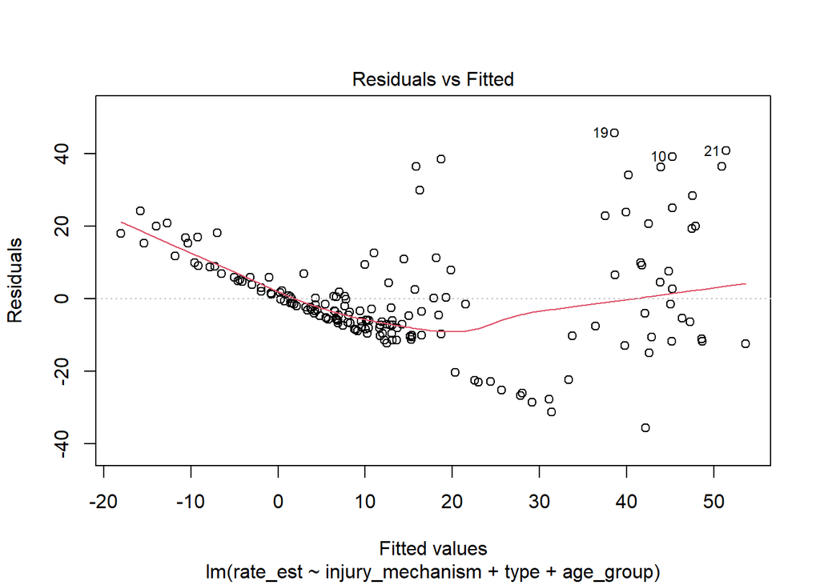

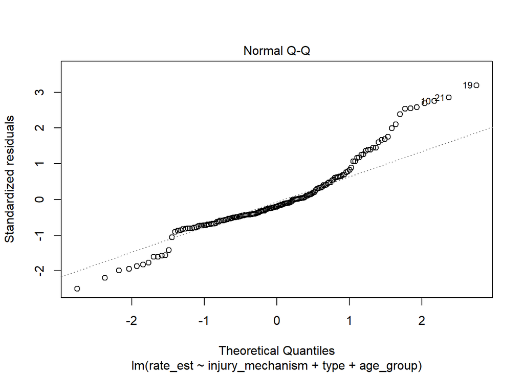

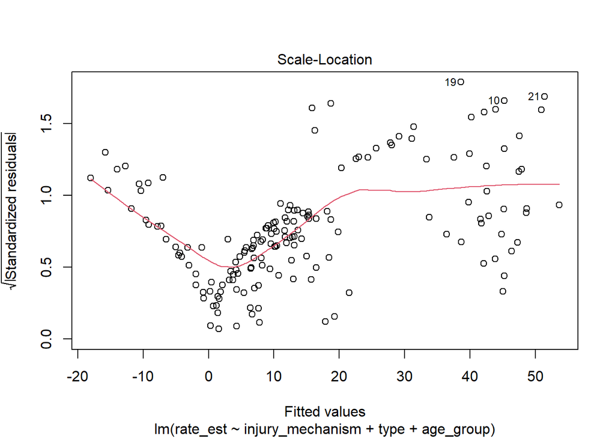

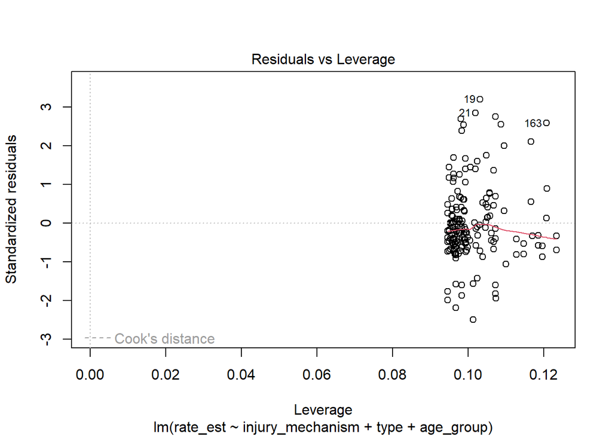

```r
plot(tbiAgeNoOutliersModel7th)
```

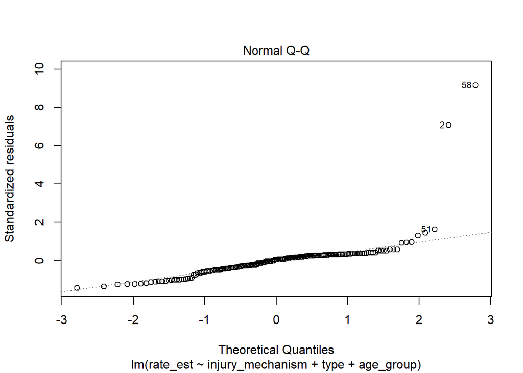

```r
# Checking normality assumptions
plot(x = tbiAgeModel, which = 2)
```

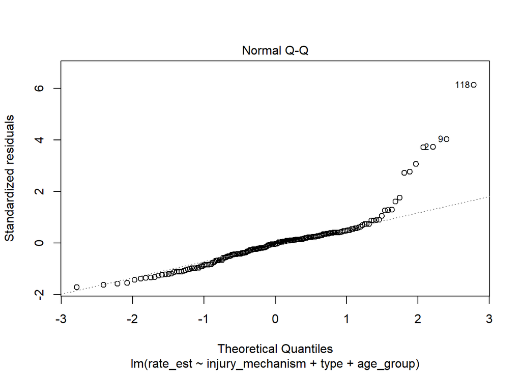

```r
plot(x = tbiAgeNoOutliersModel, which = 2)
```

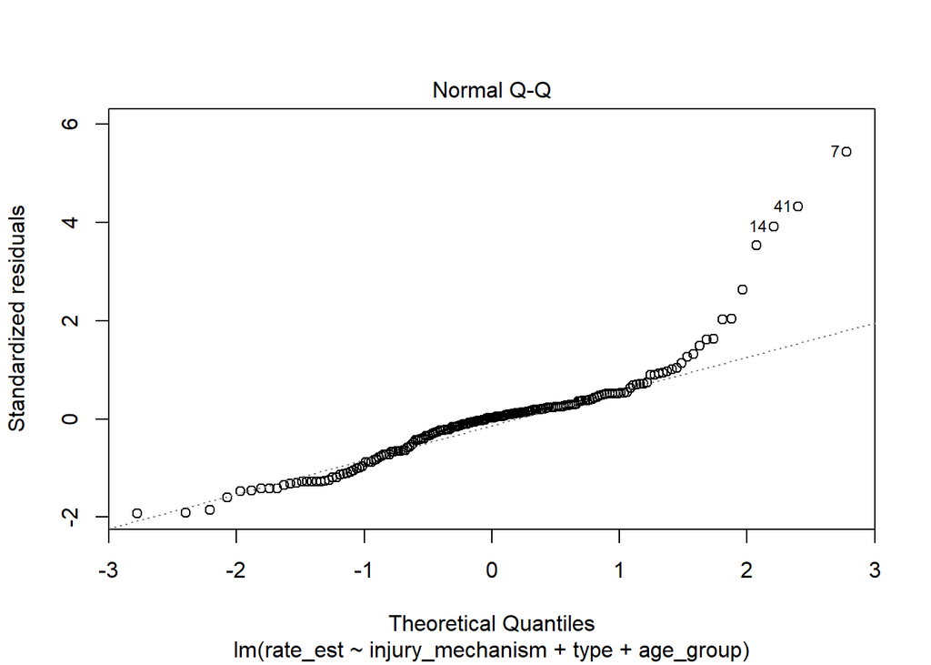

```r
plot(x = tbiAgeNoOutliersModel2nd, which = 2)
```

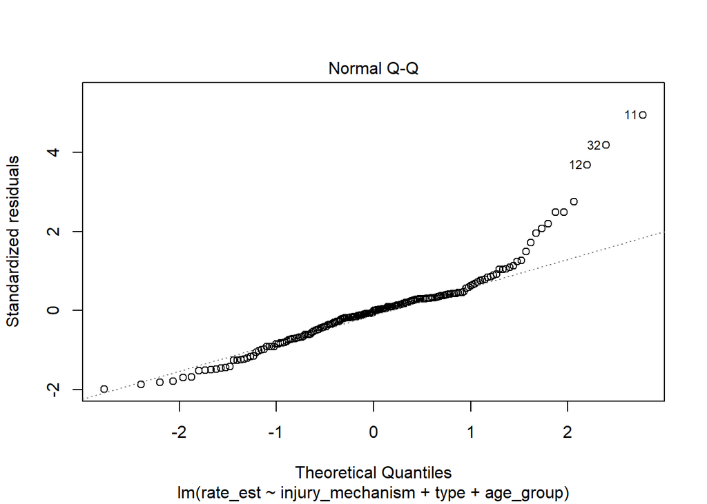

```r
plot(x = tbiAgeNoOutliersModel3rd, which = 2)
```

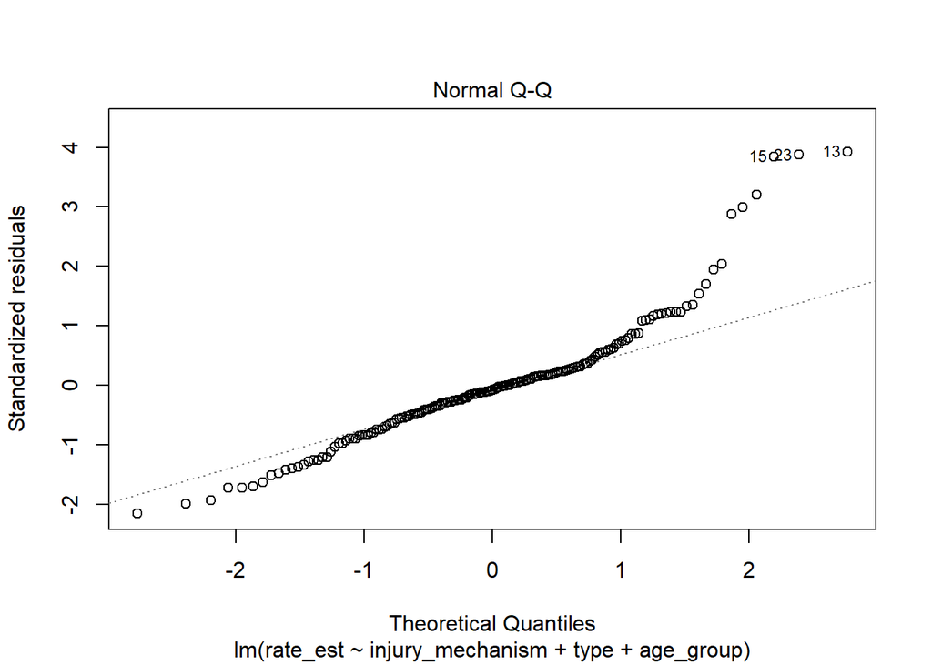

```r
plot(x = tbiAgeNoOutliersModel4th, which = 2)
```

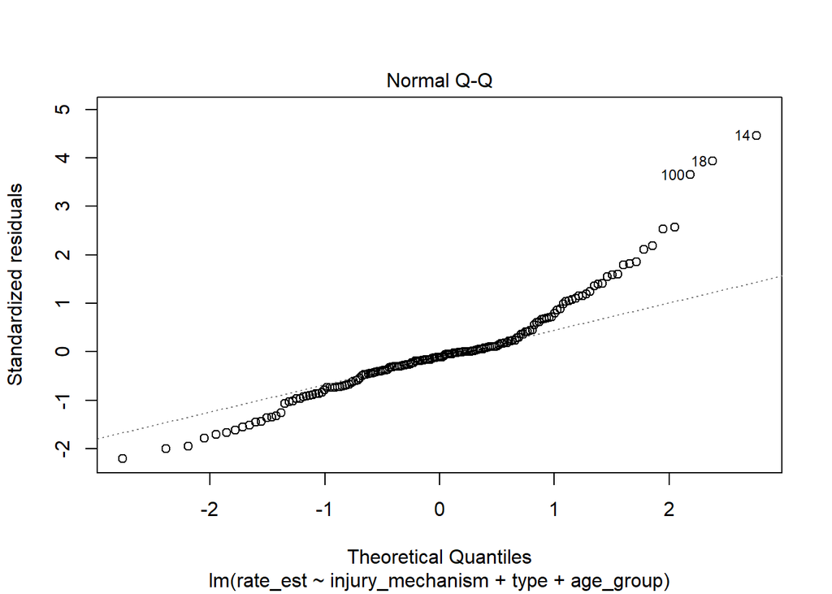

```r
plot(x = tbiAgeNoOutliersModel5th, which = 2)
```

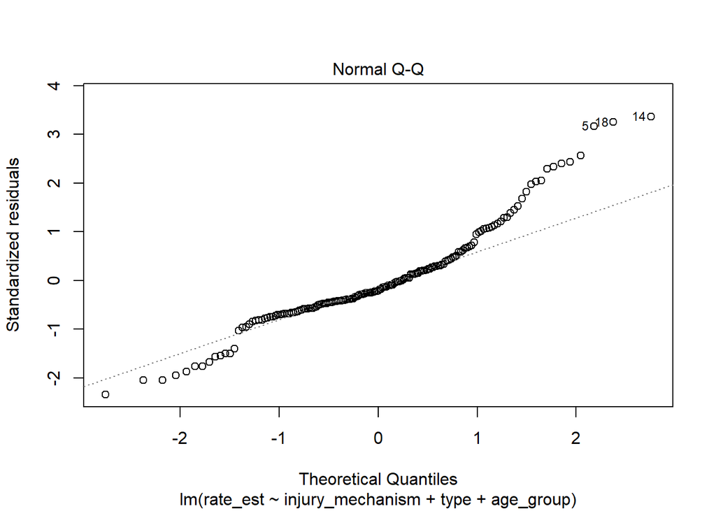

```r
plot(x = tbiAgeNoOutliersModel6th, which = 2)
```

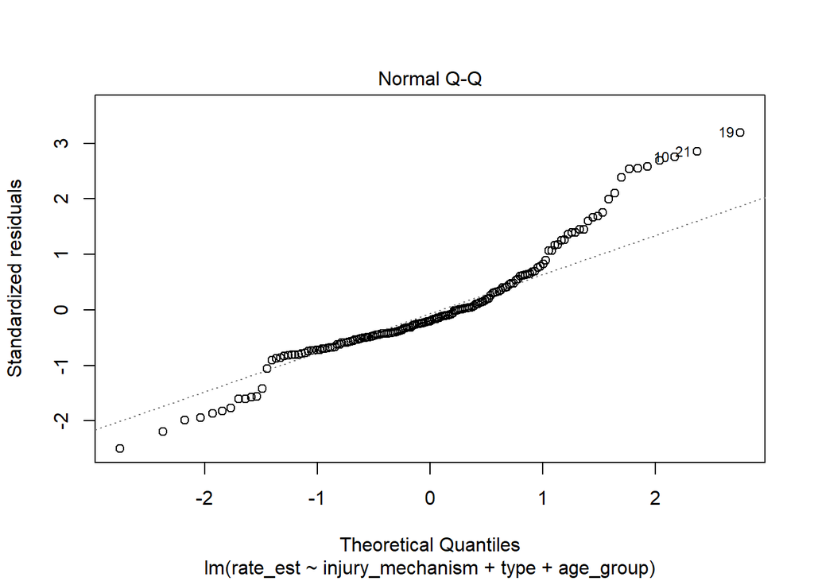

```r
plot(x = tbiAgeNoOutliersModel7th, which = 2)
```

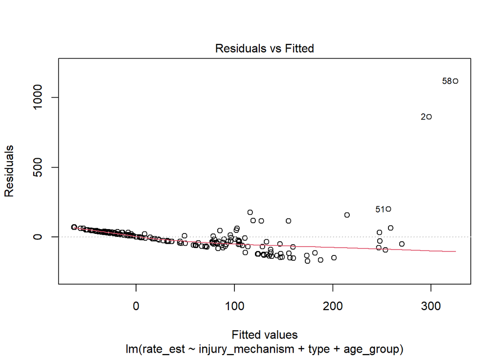

```r
# Checking linearity assumptions
plot(x = tbiAgeModel, which = 1)
```

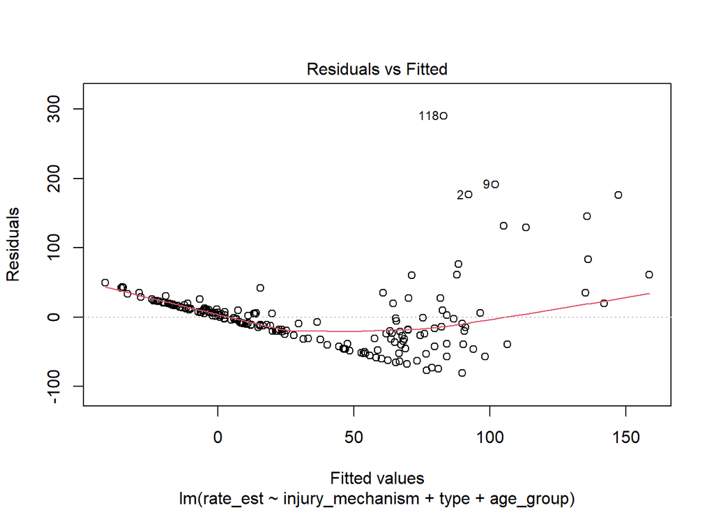

```r
plot(x = tbiAgeNoOutliersModel, which = 1)
```

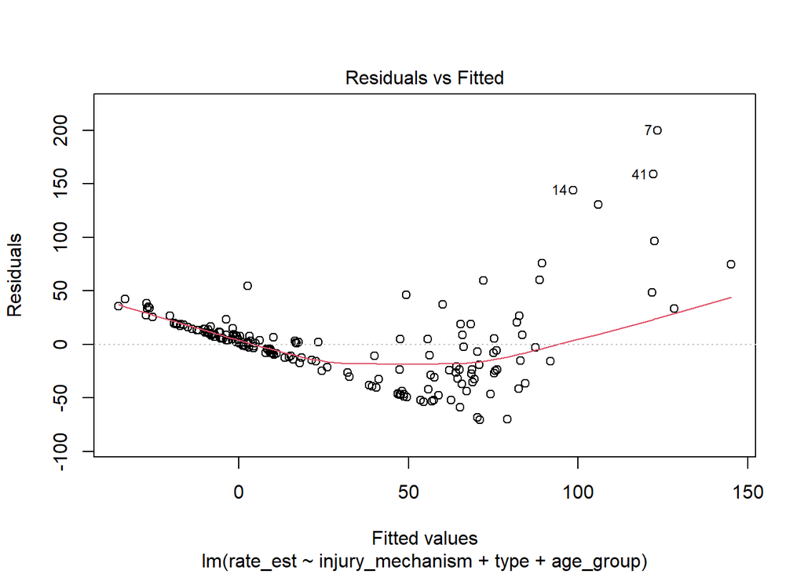

```r
plot(x = tbiAgeNoOutliersModel2nd, which = 1)
```

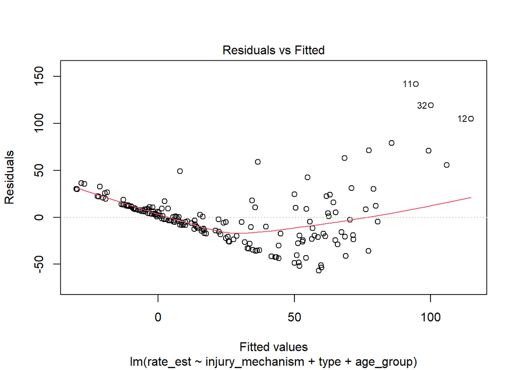

```r
plot(x = tbiAgeNoOutliersModel3rd, which = 1)
```

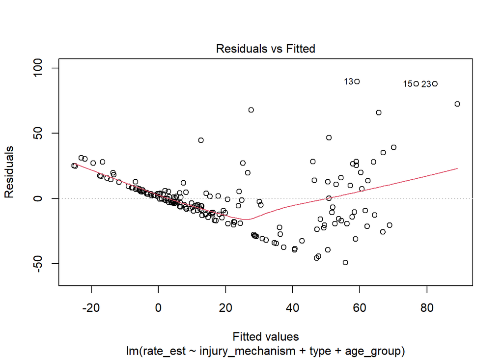

```r
plot(x = tbiAgeNoOutliersModel4th, which = 1)
```

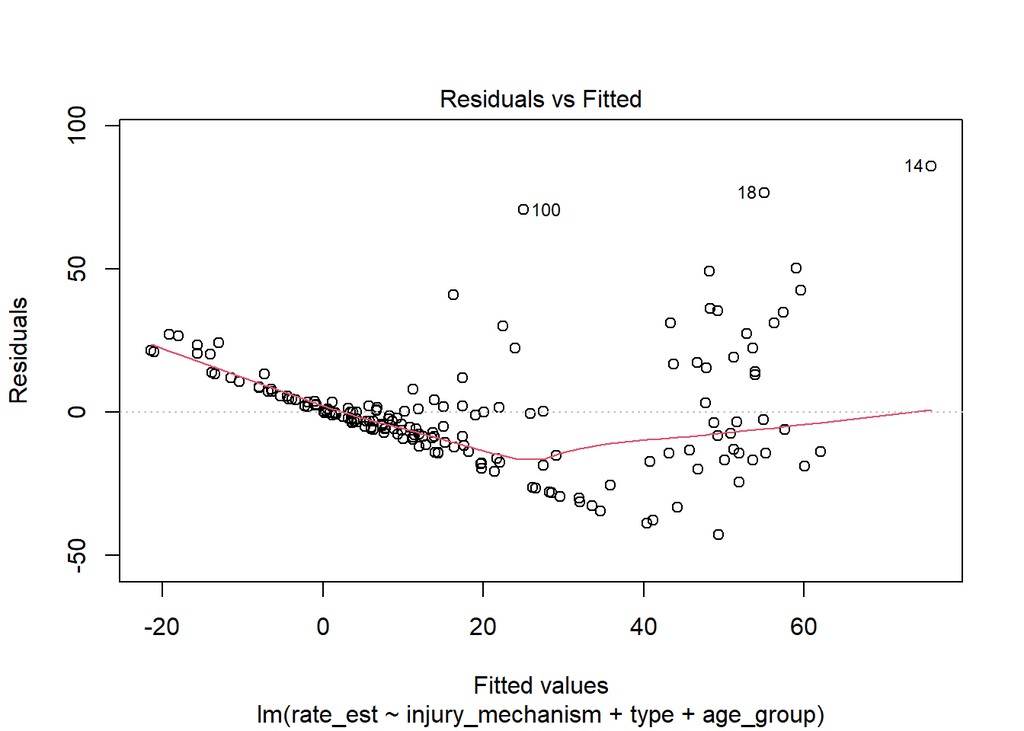

```r
plot(x = tbiAgeNoOutliersModel5th, which = 1)
```

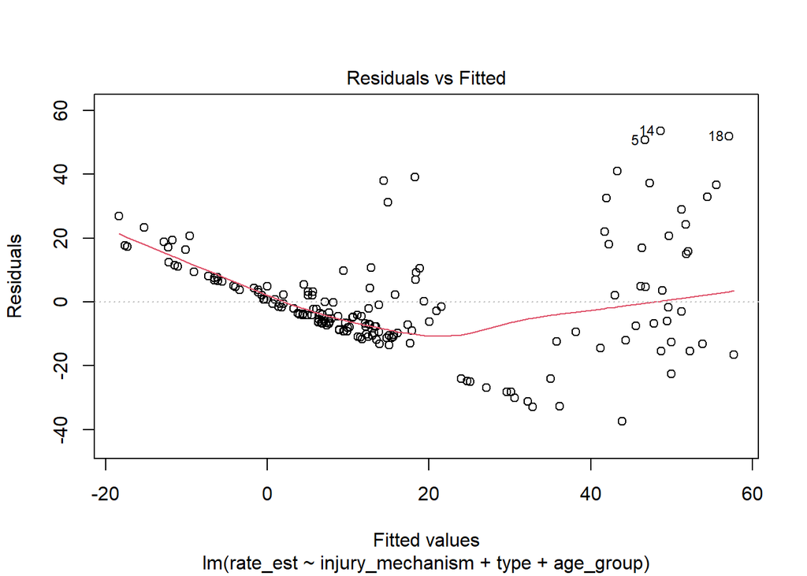

```r
plot(x = tbiAgeNoOutliersModel6th, which = 1)
```

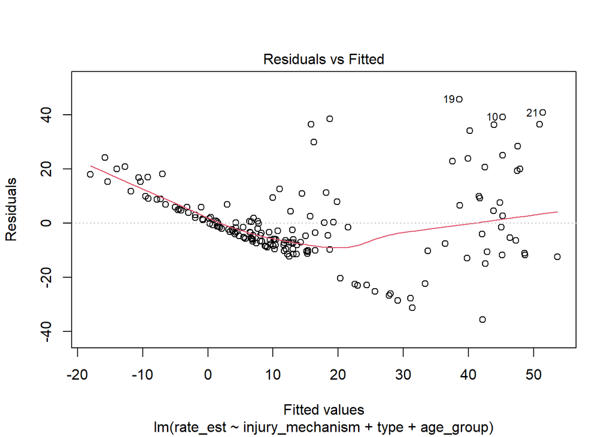

```r
plot(x = tbiAgeNoOutliersModel7th, which = 1)
```

```r
# Checking homogeneity of variance
bptest(tbiAgeModel, varformula = NULL, studentize = TRUE, data = list(), weights = NULL)
```

```
##
##  studentized Breusch-Pagan test
##
## data:  tbiAgeModel
## BP = 27.854, df = 16, p-value = 0.03291
```

```r
bptest(tbiAgeNoOutliersModel, varformula = NULL, studentize = TRUE, data = list(), weights = NULL)
```

```
##
##  studentized Breusch-Pagan test
##
## data:  tbiAgeNoOutliersModel
## BP = 35.684, df = 16, p-value = 0.003201
```

```r
bptest(tbiAgeNoOutliersModel2nd, varformula = NULL, studentize = TRUE, data = list(), weights = NULL)
```

```
##
##  studentized Breusch-Pagan test
##
## data:  tbiAgeNoOutliersModel2nd
## BP = 51.719, df = 16, p-value = 1.216e-05
```

```r
bptest(tbiAgeNoOutliersModel3rd, varformula = NULL, studentize = TRUE, data = list(), weights = NULL)
```

```
##
##  studentized Breusch-Pagan test
##
## data:  tbiAgeNoOutliersModel3rd
## BP = 58.027, df = 16, p-value = 1.121e-06
```

```r
bptest(tbiAgeNoOutliersModel4th, varformula = NULL, studentize = TRUE, data = list(), weights = NULL)
```

```
##
##  studentized Breusch-Pagan test
##
## data:  tbiAgeNoOutliersModel4th
## BP = 60.053, df = 16, p-value = 5.127e-07
```

```r
bptest(tbiAgeNoOutliersModel5th, varformula = NULL, studentize = TRUE, data = list(), weights = NULL)
```

```
##
##  studentized Breusch-Pagan test
##
## data:  tbiAgeNoOutliersModel5th
## BP = 56.222, df = 16, p-value = 2.236e-06
```

```r
bptest(tbiAgeNoOutliersModel6th, varformula = NULL, studentize = TRUE, data = list(), weights = NULL)
```

```
##
##  studentized Breusch-Pagan test
##
## data:  tbiAgeNoOutliersModel6th
## BP = 57.741, df = 16, p-value = 1.252e-06
```

```r
bptest(tbiAgeNoOutliersModel7th, varformula = NULL, studentize = TRUE, data = list(), weights = NULL)
```

```
##
##  studentized Breusch-Pagan test
##
## data:  tbiAgeNoOutliersModel7th
## BP = 60.784, df = 16, p-value = 3.859e-07
```

```r
# Checking multicollinearity assumptions
vif(tbiAgeModel)
```

```
##                  GVIF Df GVIF^(1/(2*Df))
## injury_mechanism    1  6               1
## type                1  2               1
## age_group           1  8               1
```

```r
vif(tbiAgeNoOutliersModel)
```

```
##                      GVIF Df GVIF^(1/(2*Df))
## injury_mechanism 1.007444  6        1.000618
## type             1.004963  2        1.001238
## age_group        1.004963  8        1.000309
```

```r
vif(tbiAgeNoOutliersModel2nd)
```

```
##                      GVIF Df GVIF^(1/(2*Df))
## injury_mechanism 1.015367  6        1.001272
## type             1.007125  2        1.001776
## age_group        1.014214  8        1.000883
```

```r
vif(tbiAgeNoOutliersModel3rd)
```

```
##                      GVIF Df GVIF^(1/(2*Df))
## injury_mechanism 1.025786  6        1.002124
## type             1.016905  2        1.004200
## age_group        1.016798  8        1.001042
```

```r
vif(tbiAgeNoOutliersModel4th)
```

```
##                      GVIF Df GVIF^(1/(2*Df))
## injury_mechanism 1.038542  6        1.003156
## type             1.032792  2        1.008099
## age_group        1.018934  8        1.001173
```

```r
vif(tbiAgeNoOutliersModel5th)
```

```
##                      GVIF Df GVIF^(1/(2*Df))
## injury_mechanism 1.048875  6        1.003984
## type             1.043420  2        1.010683
## age_group        1.021218  8        1.001313
```

```r
vif(tbiAgeNoOutliersModel6th)
```

```
##                      GVIF Df GVIF^(1/(2*Df))
## injury_mechanism 1.062164  6        1.005038
## type             1.058063  2        1.014210
## age_group        1.023919  8        1.001478
```

```r
vif(tbiAgeNoOutliersModel7th)
```

```
##                      GVIF Df GVIF^(1/(2*Df))
## injury_mechanism 1.067510  6        1.005459
## type             1.064586  2        1.015770
## age_group        1.031756  8        1.001956
```

```r
# Comparing models
AIC(tbiAgeModel)
```

```
## [1] 2387.943
```

```r
AIC(tbiAgeNoOutliersModel)
```

```
## [1] 1998.971
```

```r
AIC(tbiAgeNoOutliersModel2nd)
```

```
## [1] 1875.101
```

```r
AIC(tbiAgeNoOutliersModel3rd)
```

```
## [1] 1754.448
```

```r
AIC(tbiAgeNoOutliersModel4th)
```

```
## [1] 1646.365
```

```r
AIC(tbiAgeNoOutliersModel5th)
```

```
## [1] 1562.708
```

```r
AIC(tbiAgeNoOutliersModel6th)
```

```
## [1] 1469.298
```

```r
AIC(tbiAgeNoOutliersModel7th)
```

```
## [1] 1406.968
```

The normality, the linearity and the homogeneity of variance do not hold up in either of the models. There are no issues with multicollinearity. The best fit model I got was the one after the 7th iteration of removing outlier rows still wasn’t a good fit to identify the risks with high certainty.

# Evaluation

```r
summary(tbiAgeNoOutliersModel7th)
```

```
##
## Call:
## lm(formula = rate_est ~ injury_mechanism + type + age_group,
##     data = tbiAgeFilteredNoOutliers7th)
##
## Residuals:
##     Min      1Q  Median      3Q     Max
## -35.768  -7.789  -2.857   5.844  45.728
##
## Coefficients:
##                                                                   Estimate
## (Intercept)                                                         31.113
## injury_mechanismIntentional self-harm                              -10.784
## injury_mechanismMotor Vehicle Crashes                               11.457
## injury_mechanismOther or no mechanism specified                      8.710
## injury_mechanismOther unintentional injury, mechanism unspecified    6.420
## injury_mechanismUnintentional Falls                                 12.013
## injury_mechanismUnintentionally struck by or against an object       5.317
## typeHospitalizations                                               -32.142
## typeDeaths                                                         -38.358
## age_group5-14                                                        2.672
## age_group15-24                                                       7.698
## age_group25-34                                                       4.033
## age_group35-44                                                       7.459
## age_group45-54                                                       8.817
## age_group55-64                                                       5.312
## age_group65-74                                                       2.254
## age_group75+                                                        11.054
##                                                                   Std. Error
## (Intercept)                                                            4.945
## injury_mechanismIntentional self-harm                                  4.198
## injury_mechanismMotor Vehicle Crashes                                  4.318
## injury_mechanismOther or no mechanism specified                        4.237
## injury_mechanismOther unintentional injury, mechanism unspecified      4.198
## injury_mechanismUnintentional Falls                                    4.906
## injury_mechanismUnintentionally struck by or against an object         4.370
## typeHospitalizations                                                   3.051
## typeDeaths                                                             3.047
## age_group5-14                                                          4.970
## age_group15-24                                                         5.117
```

[output cut: 33 more lines]

```
## typeDeaths                                                         < 2e-16 ***
## age_group5-14                                                      0.59156
## age_group15-24                                                     0.13456
## age_group25-34                                                     0.43182
## age_group35-44                                                     0.13595
## age_group45-54                                                     0.07478 .
## age_group55-64                                                     0.28143
## age_group65-74                                                     0.65153
## age_group75+                                                       0.02797 *
## ---
## Signif. codes:  0 '***' 0.001 '**' 0.01 '*' 0.05 '.' 0.1 ' ' 1
##
## Residual standard error: 15.1 on 151 degrees of freedom
## Multiple R-squared:  0.5893, Adjusted R-squared:  0.5457
## F-statistic: 13.54 on 16 and 151 DF,  p-value: < 2.2e-16
```

```r
tab_model(tbiAgeNoOutliersModel7th)
```

|  | rate_est |  |  |
| --- | --- | --- | --- |
| Predictors | Estimates | CI | p |
| (Intercept) | 31.11 | 21.34 – 40.88 | **<0.001** |
| injury mechanism [Intentional self-harm] | -10.78 | -19.08 – -2.49 | **0.011** |
| injury mechanism [Motor Vehicle Crashes] | 11.46 | 2.93 – 19.99 | **0.009** |
| injury mechanism [Other or no mechanism specified] | 8.71 | 0.34 – 17.08 | **0.042** |
| injury mechanism [Other unintentional injury, mechanism unspecified] | 6.42 | -1.87 – 14.71 | 0.128 |
| injury mechanism [Unintentional Falls] | 12.01 | 2.32 – 21.71 | **0.015** |
| injury mechanism [Unintentionally struck by or against an object] | 5.32 | -3.32 – 13.95 | 0.226 |
| type [Hospitalizations] | -32.14 | -38.17 – -26.11 | **<0.001** |
| type [Deaths] | -38.36 | -44.38 – -32.34 | **<0.001** |
| age_group5-14 | 2.67 | -7.15 – 12.49 | 0.592 |
| age_group15-24 | 7.70 | -2.41 – 17.81 | 0.135 |
| age_group25-34 | 4.03 | -6.08 – 14.14 | 0.432 |
| age_group35-44 | 7.46 | -2.37 – 17.29 | 0.136 |
| age_group45-54 | 8.82 | -0.89 – 18.53 | 0.075 |
| age_group55-64 | 5.31 | -4.40 – 15.02 | 0.281 |
| age_group65-74 | 2.25 | -7.59 – 12.10 | 0.652 |
| age group [75+] | 11.05 | 1.21 – 20.90 | **0.028** |
| Observations | 168 |  |  |
| R<sup>2</sup> / R<sup>2</sup> adjusted | 0.589 / 0.546 |  |  |

It is confirmed that Intentional Self-Harm (Estimate=-10.78, p=0.011) is among the lowest risk of separately identified mechanism for a TBI. The highest were identified to be Unintentional Falls (Estimate=12.01, p=0.015), and Motor Vehicle Crashes (Estimate=11.46, p=0.009) respectively.

There is a statistical significance of a TBI being admitted to the Emergency Department won’t end up in further Hospitalization (Estimate=-32.14, p<0.001) nor Death (Estimate=-38.36, p<0.001).

There is a significant risk for the elderly age group (75+) for having TBI-type injuries (Estimate=11.05, p=0.028).

# Discussion

We’ve seen we can assess higher risk individuals on a single-dimension basis to identify potential TBI patient groups. The available data set isn’t well powered to identify underlying connections between separate age groups or injury mechanisms. Further research is needed to confirm relationships between age groups and exposures to injury risk.